# Notebook 2 - NLP Core

```python
import pandas as pd
import numpy as np
import warnings
warnings.filterwarnings("ignore")
import seaborn as sns
import matplotlib.pyplot as plt
import tensorflow
import tensorflow.keras as k
df2=pd.read_csv("Data Set - industrial_safety_and_health_database_with_accidents_description.csv")

df2.head()
df2.drop("Unnamed: 0",axis=1,inplace=True)
```

```python
df2.head()
```

|  | Data | Countries | Local | Industry Sector | Accident Level | Potential Accident Level | Genre | Employee or Third Party | Critical Risk | Description |
| --- | --- | --- | --- | --- | --- | --- | --- | --- | --- | --- |
| 0 | 2016-01-01 00:00:00 | Country_01 | Local_01 | Mining | I | IV | Male | Third Party | Pressed | While removing the drill rod of the Jumbo 08 f... |
| 1 | 2016-01-02 00:00:00 | Country_02 | Local_02 | Mining | I | IV | Male | Employee | Pressurized Systems | During the activation of a sodium sulphide pum... |
| 2 | 2016-01-06 00:00:00 | Country_01 | Local_03 | Mining | I | III | Male | Third Party (Remote) | Manual Tools | In the sub-station MILPO located at level +170... |
| 3 | 2016-01-08 00:00:00 | Country_01 | Local_04 | Mining | I | I | Male | Third Party | Others | Being 9:45 am. approximately in the Nv. 1880 C... |
| 4 | 2016-01-10 00:00:00 | Country_01 | Local_04 | Mining | IV | IV | Male | Third Party | Others | Approximately at 11:45 a.m. in circumstances t... |

```python
from nltk.tokenize import word_tokenize
```

```python
df=df2[["Accident Level","Description"]]
```

```python
#word_tokenize(df["Description"])
```

```python
df.columns=["Target","Text"]
```

```python
df["Target"]=df["Target"].astype("category")
```

```python
df
```

|  | Target | Text |
| --- | --- | --- |
| 0 | I | While removing the drill rod of the Jumbo 08 f... |
| 1 | I | During the activation of a sodium sulphide pum... |
| 2 | I | In the sub-station MILPO located at level +170... |
| 3 | I | Being 9:45 am. approximately in the Nv. 1880 C... |
| 4 | IV | Approximately at 11:45 a.m. in circumstances t... |
| ... | ... | ... |
| 420 | I | Being approximately 5:00 a.m. approximately, w... |
| 421 | I | The collaborator moved from the infrastructure... |
| 422 | I | During the environmental monitoring activity i... |
| 423 | I | The Employee performed the activity of strippi... |
| 424 | I | At 10:00 a.m., when the assistant cleaned the ... |

425 rows × 2 columns

```python
from dateutil.parser import parse

#########################################################
# Eliminating date and time entry strings
#########################################################
def is_date(string, fuzzy=False):
    try:
        parse(string, fuzzy=fuzzy)
        return True
    except ValueError:
        return False
#########################################################
# Function giving us cleaned word tokens
#########################################################
```

```python
import nltk
nltk.download("stopwords")
nltk.download("punkt")
nltk.download("words")
nltk.download("wordnet")
#########################################################
# Function giving us cleaned word tokens
#########################################################
def word_processing(text_input):
    from nltk.tokenize import word_tokenize
    from nltk.corpus import stopwords
    stopwords=stopwords.words('english')
    import string
    from dateutil.parser import parse
    from string import punctuation as punct
    ###################################################
    # We can use this for further analysis if wanted.
    def is_date(string, fuzzy=False):
        try:
            parse(string, fuzzy=fuzzy)
            return True
        except ValueError:
            return False
    ##################################################
    from nltk.corpus import words as eng_words
    text=word_tokenize(text_input)
    text=[word.lower() for word in text if word not in stopwords]
    text=[word for word in text if word not in punct]
    text=[word for word in text if not is_date(word)]
    text=[word for word in text if word in eng_words.words()]
    return text
######################################################
# End of Function
######################################################
```

```python
df["tokens"]=dview.map_sync(word_processing,df["Text"])

#df["tokens"]=df["Text"].apply(word_processing)
```

```python
df["count"]=df["tokens"].apply(len)
```

```python
from nltk.tokenize import word_tokenize
df["count2"]=df["Text"].apply(word_tokenize).apply(len)
```

```python
df["diff"]=df["count2"]-df["count"]
```

```python
df.head()
```

|  | Target | Text | tokens | count | count2 | diff |
| --- | --- | --- | --- | --- | --- | --- |
| 0 | I | While removing the drill rod of the Jumbo 08 f... | [while, removing, drill, rod, jumbo, maintenan... | 33 | 84 | 51 |
| 1 | I | During the activation of a sodium sulphide pum... | [during, activation, sodium, sulphide, pump, p... | 26 | 59 | 33 |
| 2 | I | In the sub-station MILPO located at level +170... | [in, level, collaborator, excavation, work, pi... | 23 | 62 | 39 |
| 3 | I | Being 9:45 am. approximately in the Nv. 1880 C... | [being, approximately, personnel, task, unlock... | 36 | 110 | 74 |
| 4 | IV | Approximately at 11:45 a.m. in circumstances t... | [approximately, mechanics, group, leader, eric... | 27 | 100 | 73 |

```python
df.to_json("master_df.json")
```

```python
df["diff"].describe()
```

```
count    425.000000
mean      44.929412
std       23.973348
min        9.000000
25%       26.000000
50%       41.000000
75%       56.000000
max      137.000000
Name: diff, dtype: float64
```

**Observation to Note**

Note the differences in the number of genuine words and the words that are before the elimination. The difference is a key indicator of sequence structure and references to sequence of events (implied by the usage of stop words or obvious words)

```python
from nltk.corpus import stopwords
for each in stopwords.words("english"):
    #print(each)
    pass
```

```python
df
```

|  | Target | Text | tokens | count | count2 | diff |
| --- | --- | --- | --- | --- | --- | --- |
| 0 | I | While removing the drill rod of the Jumbo 08 f... | [while, removing, drill, rod, jumbo, maintenan... | 33 | 84 | 51 |
| 1 | I | During the activation of a sodium sulphide pum... | [during, activation, sodium, sulphide, pump, p... | 26 | 59 | 33 |
| 2 | I | In the sub-station MILPO located at level +170... | [in, level, collaborator, excavation, work, pi... | 23 | 62 | 39 |
| 3 | I | Being 9:45 am. approximately in the Nv. 1880 C... | [being, approximately, personnel, task, unlock... | 36 | 110 | 74 |
| 4 | IV | Approximately at 11:45 a.m. in circumstances t... | [approximately, mechanics, group, leader, eric... | 27 | 100 | 73 |
| ... | ... | ... | ... | ... | ... | ... |
| 420 | I | Being approximately 5:00 a.m. approximately, w... | [being, approximately, approximately, lifting,... | 18 | 41 | 23 |
| 421 | I | The collaborator moved from the infrastructure... | [the, collaborator, infrastructure, office, ju... | 19 | 43 | 24 |
| 422 | I | During the environmental monitoring activity i... | [during, environmental, activity, area, employ... | 18 | 49 | 31 |
| 423 | I | The Employee performed the activity of strippi... | [the, employee, activity, stripping, cathode, ... | 17 | 36 | 19 |
| 424 | I | At 10:00 a.m., when the assistant cleaned the ... | [at, assistant, floor, module, e, central, cam... | 17 | 41 | 24 |

425 rows × 6 columns

```python
df["count"].describe()
```

```
count    425.000000
mean      27.305882
std       12.828167
min        6.000000
25%       17.000000
50%       25.000000
75%       34.000000
max       84.000000
Name: count, dtype: float64
```

# Analysis for Ngram Language Model

```python
from nltk.stem import PorterStemmer
from nltk.stem import WordNetLemmatizer
from nltk import ngrams, FreqDist
from nltk.util import flatten
from nltk import ngrams
from nltk.util import skipgrams
from nltk.util import trigrams
nltk.download("wordnet")
```

```
True
```

```python
processed_text=[]
stemmer = PorterStemmer()
lemmatizer=WordNetLemmatizer()
for tokens in df["tokens"]:
    #
    lemmatized_words=[lemmatizer.lemmatize(word) for word in tokens if not word.isdigit()]
    #
    stemmed_tokens=[stemmer.stem(word) for word in lemmatized_words]
    processed_text.append(stemmed_tokens)

df["tokens"]=processed_text
df["count"]=df["tokens"].apply(len)
#word_frequency=FreqDist(flatten(processed_text))
```

```python
word_corpus=pd.Series(FreqDist(flatten(list(df["tokens"]))))
```

```python
word_corpus.sort_values(ascending=False)
```

```
the         182
caus        168
hand        167
employe     162
left        160
           ...
none          1
damag         1
civil         1
pendulum      1
laundri       1
Length: 1685, dtype: int64
```

```python
#file=open("word_corpus.json","w")
word_corpus.to_json("word_corpus.json")
```

```python
#df["tokens"][0] #Unprocessed Text
```

```python
#processed_text[0] # Processed Text
```

```python
bigrams_present=list(ngrams(flatten(list(df["tokens"])),2))
trigrams_present=list(ngrams(flatten(list(df["tokens"])),3))
skipgrams_present=list(skipgrams(flatten(list(df["tokens"])),2,2))
```

```python
#bigrams_present
```

```python
#skipgrams_present
```

```python
FreqDist(bigrams_present) # This presents a very interesting perspective
```

```
FreqDist({('left', 'hand'): 70, ('at', 'time'): 61, ('caus', 'injuri'): 57, ('right', 'hand'): 57, ('time', 'accid'): 56, ('the', 'employe'): 45, ('at', 'moment'): 27, ('finger', 'left'): 22, ('injuri', 'at'): 21, ('injuri', 'the'): 18, ...})
```

```python
FreqDist(trigrams_present)
```

```
FreqDist({('at', 'time', 'accid'): 42, ('finger', 'left', 'hand'): 21, ('injuri', 'at', 'time'): 18, ('caus', 'injuri', 'the'): 13, ('finger', 'right', 'hand'): 13, ('caus', 'injuri', 'at'): 11, ('hand', 'caus', 'injuri'): 8, ('time', 'accid', 'employe'): 8, ('there', 'allerg', 'reaction'): 8, ('lef…
```

```python
FreqDist(skipgrams_present)
```

```
FreqDist({('left', 'hand'): 71, ('at', 'time'): 62, ('caus', 'injuri'): 61, ('right', 'hand'): 57, ('time', 'accid'): 57, ('the', 'employe'): 48, ('at', 'accid'): 43, ('finger', 'hand'): 38, ('hand', 'caus'): 29, ('right', 'caus'): 27, ...})
```

Keeping only top 5 bigrams and top 5 trigrams here

```python
#########################################################
# Function giving us the actual bigrams
#########################################################
def extract_ngrams(data):
    out=[]
    for i in range(len(data)):
        out.append(data[i][0])
    return out
#########################################################
# End of Function
#########################################################
```

```python
#########################################################
# Function giving us the bigram distribution across the data table
#########################################################

def ngram_df(dataframe_tokens,no,skip=False):
    df=dataframe_tokens
    if skip:
        k=df.apply(skipgrams,k=3,n=no).apply(list) # Here "k" can be changed and shifted
        n_gram=skipgram_data
    else:
        k=df.apply(ngrams,n=no).apply(list)
        if no==2:
            n_gram=bigram_data
        else:
            n_gram=trigram_data
    master_data=[]
    for each in k:
        bi_list=[]
        for i in range(len(bigram_data)):
            bi_list.append(each.count(n_gram[i]))
        #print(bigram_data[0])
        #print(bi_list)
        try:
            master_data.append(bi_list)
        except:
            pass
    return pd.DataFrame(master_data,columns=n_gram)
#########################################################
# End of Function
#########################################################
```

```python
no_of_ngram=5

whole_corpus = FreqDist(flatten())

bigram_data = extract_ngrams(FreqDist(bigrams_present).most_common(no_of_ngram))
trigram_data = extract_ngrams(FreqDist(trigrams_present).most_common(no_of_ngram))
skipgram_data = extract_ngrams(FreqDist(skipgrams_present).most_common(no_of_ngram))
```

```python
skipgram_data
```

```
[('left', 'hand'),
 ('at', 'time'),
 ('caus', 'injuri'),
 ('right', 'hand'),
 ('time', 'accid')]
```

```python
df_bigram=ngram_df(df["tokens"],no=2)
df_trigram=ngram_df(df["tokens"],no=3)
df_skipgram=ngram_df(df["tokens"],2,skip=True)
```

```python
df_skipgram
```

|  | (left, hand) | (at, time) | (caus, injuri) | (right, hand) | (time, accid) |
| --- | --- | --- | --- | --- | --- |
| 0 | 0 | 0 | 0 | 0 | 0 |
| 1 | 0 | 0 | 0 | 0 | 0 |
| 2 | 0 | 0 | 1 | 0 | 0 |
| 3 | 1 | 0 | 1 | 0 | 0 |
| 4 | 0 | 0 | 1 | 0 | 0 |
| ... | ... | ... | ... | ... | ... |
| 420 | 0 | 0 | 0 | 0 | 0 |
| 421 | 0 | 0 | 1 | 0 | 0 |
| 422 | 1 | 0 | 0 | 0 | 0 |
| 423 | 1 | 0 | 0 | 0 | 0 |
| 424 | 0 | 0 | 0 | 0 | 0 |

425 rows × 5 columns

These are the bigram, tri-gram and skip gram encodings of the text, to be loaded for further analysis, for indicators of the fields of deciding what to use.

## Analysis for bigrams

```python
df_bigram=df.join([df_bigram,df2[["Accident Level","Potential Accident Level","Industry Sector","Critical Risk"]]])
```

```python
df_bigram
```

|  | Target | Text | tokens | count | count2 | diff | (left, hand) | (at, time) | (caus, injuri) | (right, hand) | (time, accid) | Accident Level | Potential Accident Level | Industry Sector | Critical Risk |
| --- | --- | --- | --- | --- | --- | --- | --- | --- | --- | --- | --- | --- | --- | --- | --- |
| 0 | I | While removing the drill rod of the Jumbo 08 f... | [while, remov, drill, rod, jumbo, mainten, sup... | 33 | 84 | 51 | 0 | 0 | 0 | 0 | 0 | I | IV | Mining | Pressed |
| 1 | I | During the activation of a sodium sulphide pum... | [dure, activ, sodium, sulphid, pump, pipe, unc... | 26 | 59 | 33 | 0 | 0 | 0 | 0 | 0 | I | IV | Mining | Pressurized Systems |
| 2 | I | In the sub-station MILPO located at level +170... | [in, level, collabor, excav, work, pick, hand,... | 23 | 62 | 39 | 0 | 0 | 1 | 0 | 0 | I | III | Mining | Manual Tools |
| 3 | I | Being 9:45 am. approximately in the Nv. 1880 C... | [be, approxim, personnel, task, unlock, machin... | 36 | 110 | 74 | 1 | 0 | 1 | 0 | 0 | I | I | Mining | Others |
| 4 | IV | Approximately at 11:45 a.m. in circumstances t... | [approxim, mechan, group, leader, eric, three,... | 27 | 100 | 73 | 0 | 0 | 1 | 0 | 0 | IV | IV | Mining | Others |
| ... | ... | ... | ... | ... | ... | ... | ... | ... | ... | ... | ... | ... | ... | ... | ... |
| 420 | I | Being approximately 5:00 a.m. approximately, w... | [be, approxim, approxim, lift, kelli, toward, ... | 18 | 41 | 23 | 0 | 0 | 0 | 0 | 0 | I | III | Mining | Others |
| 421 | I | The collaborator moved from the infrastructure... | [the, collabor, infrastructur, offic, julio, p... | 19 | 43 | 24 | 0 | 0 | 1 | 0 | 0 | I | II | Mining | Others |
| 422 | I | During the environmental monitoring activity i... | [dure, environment, activ, area, employe, swar... | 18 | 49 | 31 | 1 | 0 | 0 | 0 | 0 | I | II | Metals | Venomous Animals |
| 423 | I | The Employee performed the activity of strippi... | [the, employe, activ, strip, cathod, sheet, ha... | 17 | 36 | 19 | 1 | 0 | 0 | 0 | 0 | I | II | Metals | Cut |
| 424 | I | At 10:00 a.m., when the assistant cleaned the ... | [at, assist, floor, modul, e, central, camp, s... | 17 | 41 | 24 | 0 | 0 | 0 | 0 | 0 | I | II | Mining | Fall prevention (same level) |

425 rows × 15 columns

```python
#Now grouping based on the how these bigrams are distributed.
cat=df_bigram.groupby("Accident Level")
```

**Task** Depending upon which grams is giving maximum correlation with the type of industry and also the type of disaster at hand, we can choose to retain those ngrams or just leave them. It all depends. So, think about it.

### For Level 1 Reporting

```python
cat1=cat.get_group("I")
```

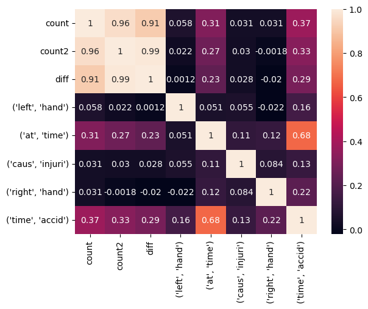

```python
sns.heatmap(cat1.corr(),annot=True)
plt.show()
```

```python
temp=cat1.iloc[:,7:12]
temp
```

|  | (at, time) | (caus, injuri) | (right, hand) | (time, accid) | Accident Level |
| --- | --- | --- | --- | --- | --- |
| 0 | 0 | 0 | 0 | 0 | I |
| 1 | 0 | 0 | 0 | 0 | I |
| 2 | 0 | 1 | 0 | 0 | I |
| 3 | 0 | 1 | 0 | 0 | I |
| 5 | 0 | 0 | 0 | 0 | I |
| ... | ... | ... | ... | ... | ... |
| 420 | 0 | 0 | 0 | 0 | I |
| 421 | 0 | 1 | 0 | 0 | I |
| 422 | 0 | 0 | 0 | 0 | I |
| 423 | 0 | 0 | 0 | 0 | I |
| 424 | 0 | 0 | 0 | 0 | I |

316 rows × 5 columns

```python
temp.sum() # The number of occurrences in this category
```

```
(at, time)                                                       46
(caus, injuri)                                                   39
(right, hand)                                                    40
(time, accid)                                                    42
Accident Level    IIIIIIIIIIIIIIIIIIIIIIIIIIIIIIIIIIIIIIIIIIIIII...
dtype: object
```

### For Level 2 Reporting

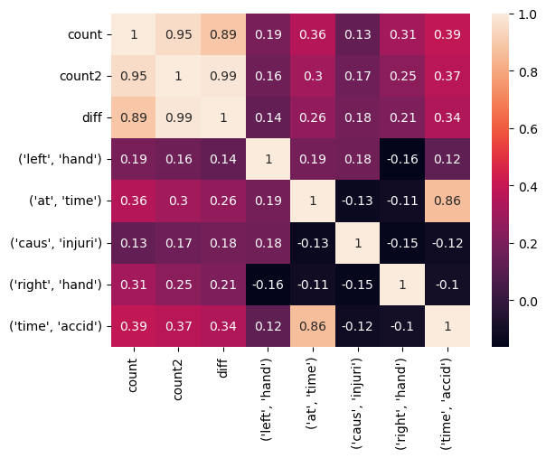

```python
cat2=cat.get_group("II")
sns.heatmap(cat2.corr(),annot=True)
plt.show()
```

```python
temp=cat2.iloc[:,7:12]
temp.sum()
```

```
(at, time)                                                        5
(caus, injuri)                                                    6
(right, hand)                                                     7
(time, accid)                                                     3
Accident Level    IIIIIIIIIIIIIIIIIIIIIIIIIIIIIIIIIIIIIIIIIIIIII...
dtype: object
```

### For Level 3 Reporting

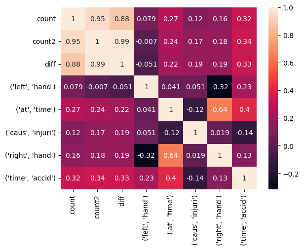

```python
cat3=cat.get_group("III")
sns.heatmap(cat3.corr(),annot=True)
plt.show()
```

```python
temp=cat3.iloc[:,7:12]
temp.sum()
```

```
(at, time)                                                        4
(caus, injuri)                                                    4
(right, hand)                                                     7
(time, accid)                                                     5
Accident Level    IIIIIIIIIIIIIIIIIIIIIIIIIIIIIIIIIIIIIIIIIIIIII...
dtype: object
```

### For Level 4 Reporting

```python
cat4=cat.get_group("IV")
sns.heatmap(cat4.corr(),annot=True)
plt.show()
```

[output not shown]

```python
temp=cat4.iloc[:,7:12]
temp.sum()
```

```
(at, time)                                                        4
(caus, injuri)                                                    8
(right, hand)                                                     2
(time, accid)                                                     4
Accident Level    IVIVIVIVIVIVIVIVIVIVIVIVIVIVIVIVIVIVIVIVIVIVIV...
dtype: object
```

```python
cat5=cat.get_group("IV")
sns.heatmap(cat5.corr(),annot=True)
plt.show()
```

[output not shown]

```python
temp=cat5.iloc[:,7:12]
temp.sum()
```

```
(at, time)                                                        4
(caus, injuri)                                                    8
(right, hand)                                                     2
(time, accid)                                                     4
Accident Level    IVIVIVIVIVIVIVIVIVIVIVIVIVIVIVIVIVIVIVIVIVIVIV...
dtype: object
```

**Important Observation**

Whenver the word "left hand" is used, it is highly likely that it is going to escalate into higher and higher levels of potential. That means, if those words every come into description, we have to be extra careful with it.

Also if the time of the accident is perfectly given by time, accident bigrams that means the accident is very well noted down and less chance of esacalating.

## Analysis of Trigrams

```python
df_trigram=df.join([df_trigram,df2[["Accident Level","Potential Accident Level","Industry Sector","Critical Risk"]]])
```

```python
#sns.histplot(data=cat3,x="Industry Sector")
```

```python
df_trigram
```

|  | Target | Text | tokens | count | count2 | diff | (at, time, accid) | (finger, left, hand) | (injuri, at, time) | (caus, injuri, the) | (finger, right, hand) | Accident Level | Potential Accident Level | Industry Sector | Critical Risk |
| --- | --- | --- | --- | --- | --- | --- | --- | --- | --- | --- | --- | --- | --- | --- | --- |
| 0 | I | While removing the drill rod of the Jumbo 08 f... | [while, remov, drill, rod, jumbo, mainten, sup... | 33 | 84 | 51 | 0 | 0 | 0 | 0 | 0 | I | IV | Mining | Pressed |
| 1 | I | During the activation of a sodium sulphide pum... | [dure, activ, sodium, sulphid, pump, pipe, unc... | 26 | 59 | 33 | 0 | 0 | 0 | 0 | 0 | I | IV | Mining | Pressurized Systems |
| 2 | I | In the sub-station MILPO located at level +170... | [in, level, collabor, excav, work, pick, hand,... | 23 | 62 | 39 | 0 | 0 | 0 | 0 | 0 | I | III | Mining | Manual Tools |
| 3 | I | Being 9:45 am. approximately in the Nv. 1880 C... | [be, approxim, personnel, task, unlock, machin... | 36 | 110 | 74 | 0 | 0 | 0 | 0 | 0 | I | I | Mining | Others |
| 4 | IV | Approximately at 11:45 a.m. in circumstances t... | [approxim, mechan, group, leader, eric, three,... | 27 | 100 | 73 | 0 | 0 | 0 | 0 | 0 | IV | IV | Mining | Others |
| ... | ... | ... | ... | ... | ... | ... | ... | ... | ... | ... | ... | ... | ... | ... | ... |
| 420 | I | Being approximately 5:00 a.m. approximately, w... | [be, approxim, approxim, lift, kelli, toward, ... | 18 | 41 | 23 | 0 | 0 | 0 | 0 | 0 | I | III | Mining | Others |
| 421 | I | The collaborator moved from the infrastructure... | [the, collabor, infrastructur, offic, julio, p... | 19 | 43 | 24 | 0 | 0 | 0 | 0 | 0 | I | II | Mining | Others |
| 422 | I | During the environmental monitoring activity i... | [dure, environment, activ, area, employe, swar... | 18 | 49 | 31 | 0 | 1 | 0 | 0 | 0 | I | II | Metals | Venomous Animals |
| 423 | I | The Employee performed the activity of strippi... | [the, employe, activ, strip, cathod, sheet, ha... | 17 | 36 | 19 | 0 | 1 | 0 | 0 | 0 | I | II | Metals | Cut |
| 424 | I | At 10:00 a.m., when the assistant cleaned the ... | [at, assist, floor, modul, e, central, camp, s... | 17 | 41 | 24 | 0 | 0 | 0 | 0 | 0 | I | II | Mining | Fall prevention (same level) |

425 rows × 15 columns

```python
#Now grouping based on the how these bigrams are distributed.
cat=df_trigram.groupby("Accident Level")
```

### For Level 1 Reporting

```python
cat1=cat.get_group("I")
```

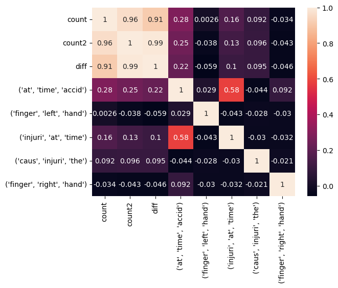

```python
sns.heatmap(cat1.corr(),annot=True)
plt.show()
```

```python
temp=cat1.iloc[:,7:12]
temp.sum()
```

```
(finger, left, hand)                                                    14
(injuri, at, time)                                                      14
(caus, injuri, the)                                                      6
(finger, right, hand)                                                    7
Accident Level           IIIIIIIIIIIIIIIIIIIIIIIIIIIIIIIIIIIIIIIIIIIIII...
dtype: object
```

### For Level 2 Reporting

```python
cat2=cat.get_group("II")
sns.heatmap(cat5.corr(),annot=True)
plt.show()
```

[output not shown]

```python
temp=cat2.iloc[:,7:12]
temp.sum()
```

```
(finger, left, hand)                                                     2
(injuri, at, time)                                                       0
(caus, injuri, the)                                                      0
(finger, right, hand)                                                    4
Accident Level           IIIIIIIIIIIIIIIIIIIIIIIIIIIIIIIIIIIIIIIIIIIIII...
dtype: object
```

### For Level 3 Reporting

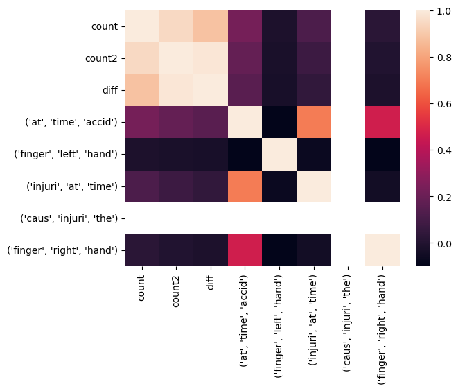

```python
cat3=cat.get_group("III")
sns.heatmap(cat3.corr())
plt.show()
```

```python
temp=cat3.iloc[:,7:12]
temp.sum()
```

```
(finger, left, hand)                                                     4
(injuri, at, time)                                                       1
(caus, injuri, the)                                                      0
(finger, right, hand)                                                    2
Accident Level           IIIIIIIIIIIIIIIIIIIIIIIIIIIIIIIIIIIIIIIIIIIIII...
dtype: object
```

### For Level 4 Reporting

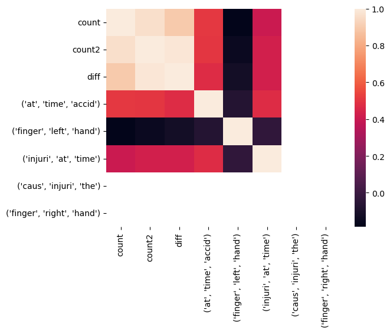

```python
cat4=cat.get_group("IV")
sns.heatmap(cat4.corr())
plt.show()
```

```python
temp=cat4.iloc[:,7:12]
temp.sum()
```

```
(finger, left, hand)                                                     1
(injuri, at, time)                                                       1
(caus, injuri, the)                                                      0
(finger, right, hand)                                                    0
Accident Level           IVIVIVIVIVIVIVIVIVIVIVIVIVIVIVIVIVIVIVIVIVIVIV...
dtype: object
```

### For Level 5 Reporting

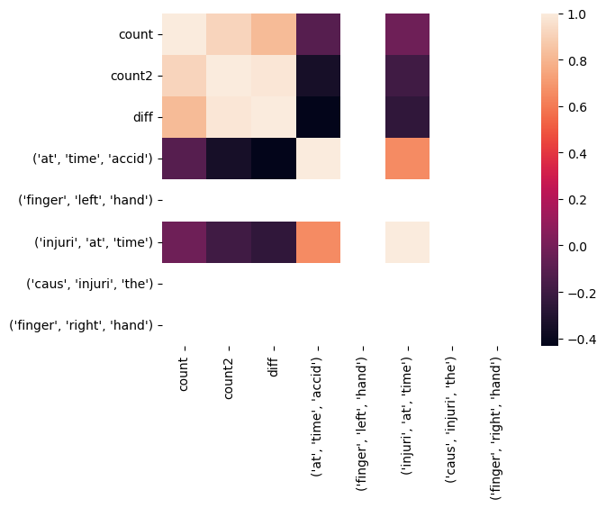

```python
cat5=cat.get_group("V")
sns.heatmap(cat5.corr())
plt.show()
```

```python
temp=cat5.iloc[:,7:12]
temp.sum()
```

```
(finger, left, hand)            0
(injuri, at, time)              1
(caus, injuri, the)             0
(finger, right, hand)           0
Accident Level           VVVVVVVV
dtype: object
```

**Observation**

It is observed here that there aren't many trigrams in use and hence don't indicate anything much about the possible data about prediction. Hence, trigrams aren't of much importance when dealing with data.

## Analysis of Skipgrams

```python
df_skipgram=df.join([df_skipgram,df2[["Accident Level","Potential Accident Level","Industry Sector","Critical Risk"]]])
```

```python
df_skipgram
```

|  | Target | Text | tokens | count | count2 | diff | (left, hand) | (at, time) | (caus, injuri) | (right, hand) | (time, accid) | Accident Level | Potential Accident Level | Industry Sector | Critical Risk |
| --- | --- | --- | --- | --- | --- | --- | --- | --- | --- | --- | --- | --- | --- | --- | --- |
| 0 | I | While removing the drill rod of the Jumbo 08 f... | [while, remov, drill, rod, jumbo, mainten, sup... | 33 | 84 | 51 | 0 | 0 | 0 | 0 | 0 | I | IV | Mining | Pressed |
| 1 | I | During the activation of a sodium sulphide pum... | [dure, activ, sodium, sulphid, pump, pipe, unc... | 26 | 59 | 33 | 0 | 0 | 0 | 0 | 0 | I | IV | Mining | Pressurized Systems |
| 2 | I | In the sub-station MILPO located at level +170... | [in, level, collabor, excav, work, pick, hand,... | 23 | 62 | 39 | 0 | 0 | 1 | 0 | 0 | I | III | Mining | Manual Tools |
| 3 | I | Being 9:45 am. approximately in the Nv. 1880 C... | [be, approxim, personnel, task, unlock, machin... | 36 | 110 | 74 | 1 | 0 | 1 | 0 | 0 | I | I | Mining | Others |
| 4 | IV | Approximately at 11:45 a.m. in circumstances t... | [approxim, mechan, group, leader, eric, three,... | 27 | 100 | 73 | 0 | 0 | 1 | 0 | 0 | IV | IV | Mining | Others |
| ... | ... | ... | ... | ... | ... | ... | ... | ... | ... | ... | ... | ... | ... | ... | ... |
| 420 | I | Being approximately 5:00 a.m. approximately, w... | [be, approxim, approxim, lift, kelli, toward, ... | 18 | 41 | 23 | 0 | 0 | 0 | 0 | 0 | I | III | Mining | Others |
| 421 | I | The collaborator moved from the infrastructure... | [the, collabor, infrastructur, offic, julio, p... | 19 | 43 | 24 | 0 | 0 | 1 | 0 | 0 | I | II | Mining | Others |
| 422 | I | During the environmental monitoring activity i... | [dure, environment, activ, area, employe, swar... | 18 | 49 | 31 | 1 | 0 | 0 | 0 | 0 | I | II | Metals | Venomous Animals |
| 423 | I | The Employee performed the activity of strippi... | [the, employe, activ, strip, cathod, sheet, ha... | 17 | 36 | 19 | 1 | 0 | 0 | 0 | 0 | I | II | Metals | Cut |
| 424 | I | At 10:00 a.m., when the assistant cleaned the ... | [at, assist, floor, modul, e, central, camp, s... | 17 | 41 | 24 | 0 | 0 | 0 | 0 | 0 | I | II | Mining | Fall prevention (same level) |

425 rows × 15 columns

**Observation**

## Conclusion Based on ngram, Skipgram Analysis

1. Enough analysis based on the separate sentence break down (sentence tokenization) needs to be done so that proper representation can be done whether the skipgrams were any effective in judging sequential relationship between data and its indicator of anyway between escalation of reported incident to higher incident.
2. Most of the bigram combinations and the wrods listed in these ngrams occupy a major chunk of the given description of any incident. Hence, it becomes important that we have to have proper analysis of unique words in the corpus and possible relation to being in any particular Industry or sector. That way, we can make sure that we can compensate the corpus data that we have as description to fill up the data, if not given by the user.
3. Given that above is not done, or if is deemed not required, we can proceed towards the suggestion that LSTM networks if used, doesn't need to process very or extremely long sequences. So, just two or 3 LSTM units are enough for the processing.
4. If it is decided that to replace words with their bigram counter parts, then it is advised that one should implement a method to repeat the same in the input data at runtime, so appropriate care is taken.

# Analysis of Word Frequencies with respect to each of the Columns

## Analyzing by Industry

```python
df3=df.join(df2[["Accident Level","Potential Accident Level","Industry Sector","Critical Risk"]]).groupby("Industry Sector")
```

```python
df2["Industry Sector"].value_counts()
```

```
Mining    241
Metals    134
Others     50
Name: Industry Sector, dtype: int64
```

```python
%store df2
%store df
```

```
Stored 'df2' (DataFrame)
Stored 'df' (DataFrame)
```

### Metals Industry

```python
cat=df3.get_group("Metals")
cat
```

|  | Target | Text | tokens | count | count2 | diff | Accident Level | Potential Accident Level | Industry Sector | Critical Risk |
| --- | --- | --- | --- | --- | --- | --- | --- | --- | --- | --- |
| 5 | I | During the unloading operation of the ustulado... | [dure, oper, bag, need, unclog, discharg, mout... | 20 | 55 | 35 | I | III | Metals | Pressurized Systems |
| 6 | I | The collaborator reports that he was on street... | [the, collabor, street, hold, left, hand, volu... | 19 | 44 | 25 | I | III | Metals | Fall prevention (same level) |
| 9 | I | At the moment the forklift operator went to ma... | [at, moment, oper, went, manipul, big, bag, bi... | 32 | 72 | 40 | I | II | Metals | Chemical substances |
| 12 | I | The collaborator reports that he was working i... | [the, collabor, work, cyclon, duct, door, tri,... | 17 | 45 | 28 | I | I | Metals | Liquid Metal |
| 14 | I | Due to the accumulation of Waelz on the convey... | [due, accumul, trailer, filter, employe, clean... | 20 | 65 | 45 | I | III | Metals | Confined space |
| ... | ... | ... | ... | ... | ... | ... | ... | ... | ... | ... |
| 402 | I | Mr. Emerson was moving trays; when climbing th... | [move, climb, staircas, access, former, dine, ... | 26 | 75 | 49 | I | III | Metals | Fall |
| 405 | I | Approx. 18:40 hours, Mr. Luis maintenance team... | [mainten, team, mobil, equip, bolt, front, loa... | 22 | 60 | 38 | I | II | Metals | Cut |
| 415 | I | Employee reports that by removing the zinc she... | [employe, remov, zinc, sheet, cathod, take, ea... | 13 | 31 | 18 | I | II | Metals | Others |
| 422 | I | During the environmental monitoring activity i... | [dure, environment, activ, area, employe, swar... | 18 | 49 | 31 | I | II | Metals | Venomous Animals |
| 423 | I | The Employee performed the activity of strippi... | [the, employe, activ, strip, cathod, sheet, ha... | 17 | 36 | 19 | I | II | Metals | Cut |

134 rows × 10 columns

```python
cat["diff"].describe()
```

```
count    134.000000
mean      28.276119
std       12.770026
min        9.000000
25%       18.000000
50%       26.000000
75%       36.000000
max       66.000000
Name: diff, dtype: float64
```

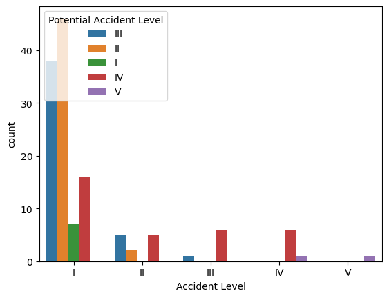

```python
sns.countplot(data=cat,x=cat["Accident Level"],hue="Potential Accident Level")
plt.show()
```

**Observations**

Simiarly once observed at level 3 it is highly likely that it is not at all sustained at level 3. It will most likely go into level 4.

But when it is observed to be at level 4 it will likely sustained at level 4 and will not move into level5.

Based on the above data we are now going to get some word frequency predicitons and how they are distributed across the potential incident levels.

```python
word_corpus.sort_values(ascending=False) # This is for the entire Corpus of the data
```

```
the         182
caus        168
hand        167
employe     162
left        160
           ...
none          1
damag         1
civil         1
pendulum      1
laundri       1
Length: 1685, dtype: int64
```

```python
corp_metal=pd.Series(FreqDist(flatten(list(cat["tokens"])))).sort_values(ascending=False)
corp_metal[:10]
#This is the Corpus of the Metal Industry for most used 10 words
```

```
employe    77
the        61
left       47
hand       46
caus       43
right      37
oper       37
activ      26
at         25
medic      24
dtype: int64
```

**Observations**

### Mining Industry

```python
cat=df3.get_group("Mining")
cat
```

|  | Target | Text | tokens | count | count2 | diff | Accident Level | Potential Accident Level | Industry Sector | Critical Risk |
| --- | --- | --- | --- | --- | --- | --- | --- | --- | --- | --- |
| 0 | I | While removing the drill rod of the Jumbo 08 f... | [while, remov, drill, rod, jumbo, mainten, sup... | 33 | 84 | 51 | I | IV | Mining | Pressed |
| 1 | I | During the activation of a sodium sulphide pum... | [dure, activ, sodium, sulphid, pump, pipe, unc... | 26 | 59 | 33 | I | IV | Mining | Pressurized Systems |
| 2 | I | In the sub-station MILPO located at level +170... | [in, level, collabor, excav, work, pick, hand,... | 23 | 62 | 39 | I | III | Mining | Manual Tools |
| 3 | I | Being 9:45 am. approximately in the Nv. 1880 C... | [be, approxim, personnel, task, unlock, machin... | 36 | 110 | 74 | I | I | Mining | Others |
| 4 | IV | Approximately at 11:45 a.m. in circumstances t... | [approxim, mechan, group, leader, eric, three,... | 27 | 100 | 73 | IV | IV | Mining | Others |
| ... | ... | ... | ... | ... | ... | ... | ... | ... | ... | ... |
| 414 | I | On the surface, Comedor the worker of the comp... | [on, surfac, worker, compani, c, c, made, cut,... | 20 | 42 | 22 | I | II | Mining | Cut |
| 419 | I | After maintenance on Boltec 03 at level 285 GT... | [after, mainten, level, mechan, oper, equip, e... | 17 | 48 | 31 | I | III | Mining | Pressed |
| 420 | I | Being approximately 5:00 a.m. approximately, w... | [be, approxim, approxim, lift, kelli, toward, ... | 18 | 41 | 23 | I | III | Mining | Others |
| 421 | I | The collaborator moved from the infrastructure... | [the, collabor, infrastructur, offic, julio, p... | 19 | 43 | 24 | I | II | Mining | Others |
| 424 | I | At 10:00 a.m., when the assistant cleaned the ... | [at, assist, floor, modul, e, central, camp, s... | 17 | 41 | 24 | I | II | Mining | Fall prevention (same level) |

241 rows × 10 columns

```python
cat["diff"].describe()
```

```
count    241.000000
mean      50.630705
std       22.718030
min       13.000000
25%       38.000000
50%       47.000000
75%       62.000000
max      137.000000
Name: diff, dtype: float64
```

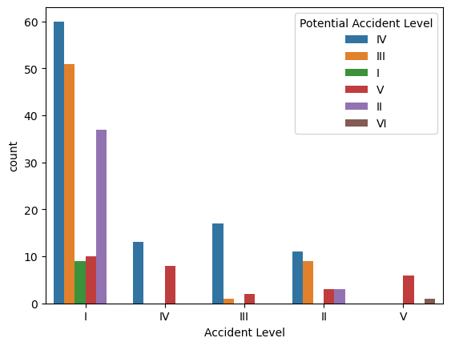

```python
sns.countplot(data=cat,x=cat["Accident Level"],hue="Potential Accident Level")
plt.show()
```

**Observations**

Extremely low number actually have the highest potential from level 4 disaster.

There is always quick escalation from level 3 to level 4 and sustenance in level 3 is very little for Mining Industry.

```python
corp_mining=pd.Series(FreqDist(flatten(list(cat["tokens"])))).sort_values(ascending=False)
corp_mining[:10]
# This is the Corpus of the Mining Industry for most used 10 words
```

```
caus      106
right     104
oper      104
hand      103
at        101
time       99
left       94
injuri     91
the        76
equip      68
dtype: int64
```

```python
corp_mining.shape
```

```
(1263,)
```

**Observations**

*The MOST IMPORTANT OBSERVATION* here is that right hand seems to be involved a lot more in the incidents related to mining than for metals. This is a very important indicator for further analysis (especially to compensate for missing data).

Most of the incidents seem to be that operation related incidents i.e. while working and not some other time. So, that is one thing we need to work out.

# Others Industry

```python
cat=df3.get_group("Others")
cat
```

|  | Target | Text | tokens | count | count2 | diff | Accident Level | Potential Accident Level | Industry Sector | Critical Risk |
| --- | --- | --- | --- | --- | --- | --- | --- | --- | --- | --- |
| 78 | II | When accessing the Santa do Novo area, in orde... | [when, area, order, open, chop, gener, move, a... | 40 | 87 | 47 | II | II | Others | Others |
| 79 | IV | When performing the sleeve removal maneuver, w... | [when, sleev, remov, maneuv, hole, deep, gener... | 76 | 202 | 126 | IV | IV | Others | Poll |
| 80 | I | During the trip to the vehicle, at the end of ... | [dure, trip, vehicl, end, work, collabor, step... | 36 | 81 | 45 | I | I | Others | Others |
| 108 | I | When performing geological mapping activity, i... | [when, geolog, activ, necessari, hammer, rock,... | 18 | 42 | 24 | I | I | Others | Manual Tools |
| 119 | I | When an employee of MILPO Lima visited the fac... | [when, employe, level, wait, personnel, cage, ... | 34 | 103 | 69 | I | II | Others | Others |
| 125 | IV | During field trip, to return to work after lun... | [dure, field, trip, return, work, lunch, emplo... | 34 | 80 | 46 | IV | IV | Others | Fall |
| 129 | I | The ground team coordinated by Prospector with... | [the, ground, team, prospector, da, silva, pro... | 47 | 127 | 80 | I | I | Others | Bees |
| 130 | I | In the geological reconnaissance activity, in ... | [in, geolog, reconnaiss, activ, farm, team, co... | 53 | 141 | 88 | I | I | Others | Bees |
| 131 | I | In the geological reconnaissance activity, in ... | [in, geolog, reconnaiss, activ, farm, team, co... | 53 | 141 | 88 | I | I | Others | Others |
| 136 | II | During the field trip, on LT 01 of the Lajes t... | [dure, field, trip, target, junior, da, costa,... | 36 | 97 | 61 | II | II | Others | Others |
| 143 | I | Project of Vazante that carried out sediment c... | [project, carri, sediment, collect, current, s... | 47 | 147 | 100 | I | I | Others | Bees |
| 144 | I | Project of Vazante that carried out sediment c... | [project, carri, sediment, collect, current, s... | 47 | 147 | 100 | I | I | Others | Others |
| 148 | I | The Geologo and the auxiliary Elismar traveled... | [the, auxiliari, travel, evalu, geolog, follow... | 45 | 120 | 75 | I | I | Others | Bees |
| 149 | I | Geologist and auxiliary Ademir traveled to the... | [geologist, auxiliari, travel, field, evalu, g... | 45 | 117 | 72 | I | I | Others | Bees |
| 150 | I | The Safety and Technical moved to the field fo... | [the, safeti, technic, field, inspect, activ, ... | 36 | 93 | 57 | I | I | Others | Bees |
| 151 | I | Auxiliary and Geologist traveled to the field ... | [auxiliari, geologist, travel, field, evalu, g... | 44 | 118 | 74 | I | I | Others | Bees |
| 152 | I | While traveling in the field in order to make ... | [while, travel, field, order, make, geolog, ge... | 23 | 63 | 40 | I | I | Others | Bees |
| 153 | I | When moving in the field to make geological ma... | [when, move, field, make, geolog, prospector, ... | 22 | 57 | 35 | I | I | Others | Bees |
| 169 | III | During execution of drilling on the target - B... | [dure, execut, drill, target, bolt, made, comp... | 60 | 151 | 91 | III | IV | Others | Others |
| 177 | I | At the Eusébio bridge, there was a sudden brak... | [at, bridg, sudden, sever, brake, quickli, the... | 16 | 45 | 29 | I | II | Others | Traffic |
| 184 | I | The mincing team was carrying out activities i... | [the, minc, team, carri, citi, mine, technicia... | 35 | 85 | 50 | I | I | Others | Bees |
| 188 | I | On leaving the Company the employee stumbled o... | [on, leav, compani, employe, onto, exit, ladde... | 14 | 29 | 15 | I | IV | Others | Others |
| 212 | III | In the city of Conchucos, of Ancash, participa... | [in, citi, patron, feast, compani, mount, hors... | 25 | 76 | 51 | III | IV | Others | Others |
| 214 | I | When cutting the vegetation to open the bite, ... | [when, cut, veget, open, bite, sickl, assist, ... | 21 | 45 | 24 | I | I | Others | Others |
| 217 | I | Collaborator around 9:00 AM, cleaning the leav... | [collabor, around, am, clean, leaf, return, we... | 25 | 67 | 42 | I | I | Others | Fall |
| 232 | III | In the probe 5068 bore BAPDD00146, around 15:0... | [in, probe, bore, around, poll, assist, da, si... | 46 | 121 | 75 | III | III | Others | Others |
| 254 | I | In the region of Povoado Vista - Martinópole -... | [in, region, vista, ce, employe, de, soil, col... | 46 | 114 | 68 | I | I | Others | Others |
| 294 | I | The auxiliary of general services I, Paulo e S... | [the, auxiliari, gener, i, e, silva, day, work... | 45 | 111 | 66 | I | IV | Others | Fall prevention |
| 306 | I | On 01/24/2017, at 12:25 a.m., during the activ... | [on, activ, soil, collabor, ran, branch, he, b... | 15 | 48 | 33 | I | I | Others | Venomous Animals |
| 313 | I | On 01/02/2017, at 10:15 a.m., when performing ... | [on, soil, activ, collabor, use, assist, open,... | 26 | 79 | 53 | I | II | Others | Projection/Choco |
| 315 | I | On 05/02/2017, at 10:40 p.m., when performing ... | [on, geolog, activ, geologist, da, silva, do, ... | 55 | 147 | 92 | I | II | Others | Others |
| 329 | I | On 02/15/2017 at 3:27 pm, when performing the ... | [on, magnetometr, collabor, top, field, hat, b... | 18 | 57 | 39 | I | I | Others | Venomous Animals |
| 338 | I | On 02/25/2017 at 13:05 p.m., when assisting wi... | [on, magnetometr, collabor, top, field, hat, b... | 62 | 189 | 127 | I | I | Others | Venomous Animals |
| 344 | I | On 02/03/17 during the soil sampling in the re... | [on, soil, sampl, region, da, silva, bee, test... | 51 | 138 | 87 | I | I | Others | Venomous Animals |
| 345 | I | On 02/03/17 during the soil sampling in the re... | [on, soil, sampl, region, da, silva, bee, test... | 51 | 138 | 87 | I | I | Others | Venomous Animals |
| 346 | I | On 02/03/17 during the soil sampling in the re... | [on, soil, sampl, region, da, silva, bee, test... | 51 | 138 | 87 | I | I | Others | Venomous Animals |
| 349 | I | On 08/03/2017 at 3:30 PM, when performing MAG ... | [on, mag, activ, employe, da, silva, move, acq... | 47 | 115 | 68 | I | I | Others | Others |
| 354 | I | Team of the VMS Project performed soil collect... | [team, project, soil, collect, target, when, m... | 44 | 129 | 85 | I | I | Others | Venomous Animals |
| 355 | I | Team of the VMS Project performed soil collect... | [team, project, soil, collect, target, when, m... | 44 | 129 | 85 | I | I | Others | Venomous Animals |
| 360 | I | The technician was doing the magnetometric sur... | [the, technician, magnetometr, survey, step, t... | 15 | 32 | 17 | I | I | Others | Others |
| 365 | I | On 04/04/2017, around 13: 30hs, during the cur... | [on, around, current, sediment, activ, collabo... | 29 | 70 | 41 | I | I | Others | Venomous Animals |
| 369 | I | During the execution of the soil sampling task... | [dure, execut, soil, sampl, task, area, around... | 31 | 94 | 63 | I | I | Others | Venomous Animals |
| 374 | I | During the execution of the service of opening... | [dure, execut, servic, open, prick, futur, wor... | 54 | 152 | 98 | I | I | Others | Venomous Animals |
| 376 | I | On 04/19/2017, the employee de Lima da Silva w... | [on, employe, de, da, silva, team, open, bite,... | 63 | 146 | 83 | I | IV | Others | Others |
| 378 | I | During the execution of the soil sampling task... | [dure, execut, soil, sampl, task, area, around... | 34 | 90 | 56 | I | I | Others | Venomous Animals |
| 392 | I | The employee, as he passed the corner of the f... | [the, employe, corner, front, door, see, sligh... | 13 | 35 | 22 | I | I | Others | Others |
| 399 | I | Upon entering the building, the maid slipped a... | [upon, enter, build, maid, slip, fell, behind,... | 16 | 30 | 14 | I | II | Others | Others |
| 416 | III | During the execution of the task of assembling... | [dure, execut, task, box, testimoni, area, aro... | 29 | 84 | 55 | III | IV | Others | Others |
| 417 | I | The technician was returning from his activiti... | [the, technician, bite, step, loos, rock, slop... | 15 | 38 | 23 | I | IV | Others | Others |
| 418 | I | During the field activity in the AMG project, ... | [dure, field, activ, project, target, reconnai... | 27 | 78 | 51 | I | I | Others | Venomous Animals |

```python
cat["diff"].describe()
```

```
count     50.000000
mean      62.080000
std       28.002799
min       14.000000
25%       41.250000
50%       62.000000
75%       85.000000
max      127.000000
Name: diff, dtype: float64
```

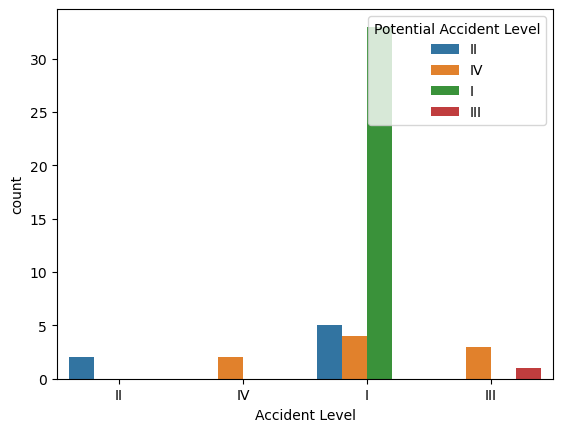

```python
sns.countplot(data=cat,x=cat["Accident Level"],hue="Potential Accident Level")
plt.show()
```

**Observations**

```python
corp_others=pd.Series(FreqDist(flatten(list(cat["tokens"])))).sort_values(ascending=False)
corp_others
```

```
the          45
employe      42
activ        30
one          26
left         19
             ..
blackjack     1
afternoon     1
sought        1
steep         1
properli      1
Length: 531, dtype: int64
```

**Observations**

Most of the time is the active employees that either observe or are somehow involved in the incidents.

Since there are less than half number of words that are used in this category compared to the rest, we can be pretty sure that much lesser number of important or useful words are there in this.

We can be pretty sure that if a certain number of words of certainly be absent, we can be sure that it is "others" category because presence of those words will more likely produce the "Mining" or "Metal" industry issues.

```python
word_corpus.index
```

```
Index(['while', 'remov', 'drill', 'rod', 'jumbo', 'mainten', 'supervisor',
       'proce', 'loosen', 'support',
       ...
       'research', 'she', 'properli', 'magazin', 'infrastructur', 'julio',
       'bra', 'environment', 'camp', 'laundri'],
      dtype='object', length=1685)
```

## Cross Analysis for Industries

```python
print("Total Number of words that in total Corpus")
len(set(word_corpus.index))
```

```
Total Number of words that in total Corpus
```

```
1685
```

```python
print("Total Number of words that are in total corpus but not in \"others\" dataset")
print(len(set(word_corpus.index)-set(corp_others.index)))
#print("Total Number of words that are in \"others\" description exclusive are ")
#print(len(set(corp_others.index)-set(word_corpus.index)))
```

```
Total Number of words that are in total corpus but not in "others" dataset
1154
```

```python
print("Total Number of words that are in total corpus but not in \"Mining\" dataset")
print(len(set(word_corpus.index)-set(corp_mining.index)))
#print("Total Number of words that are in \"mining\" description exclusive are ")
#print(len(set(corp_mining.index)-set(word_corpus.index)))
```

```
Total Number of words that are in total corpus but not in "Mining" dataset
422
```

```python
print("Total Number of words that are in total corpus but not in \"Metals\" dataset")
print(len(set(word_corpus.index)-set(corp_metal.index)))
#print("Total Number of words that are in \"metal\" description exclusive are ")
#print(len(set(corp_metal.index)-set(word_corpus.index)))
```

```
Total Number of words that are in total corpus but not in "Metals" dataset
926
```

```python
print("These are the Exclusive words in Metal Industry descriptions but not in anything else and their frequencies")

try:
    k=corp_metal[set(corp_metal.index)-set(corp_mining.index)-set(corp_others.index)].sort_values(ascending=False)
    print(k)
except:
    print("Corpus is shared and not clean")
#len(set(corp_metal.index)-set(corp_mining.index)-set(corp_others.index))
```

```
These are the Exclusive words in Metal Industry descriptions but not in anything else and their frequencies
cathod      14
boiler       6
thermal      6
degre        6
ingot        6
            ..
stepladd     1
command      1
stood        1
kiln         1
brush        1
Length: 227, dtype: int64
```

Calculating the probabiltiy of occurrence of these words that decide the industry.

```python
k/k.sum()
```

```
cathod      0.040346
boiler      0.017291
thermal     0.017291
degre       0.017291
ingot       0.017291
              ...
stepladd    0.002882
command     0.002882
stood       0.002882
kiln        0.002882
brush       0.002882
Length: 227, dtype: float64
```

```python
corp_metal.sum() # The total number of words with repeated occurrences.
```

```
2504
```

```python
k/corp_metal.sum() # The chance of the exclusive corpus occurring out of the total
```

```
cathod      0.005591
boiler      0.002396
thermal     0.002396
degre       0.002396
ingot       0.002396
              ...
stepladd    0.000399
command     0.000399
stood       0.000399
kiln        0.000399
brush       0.000399
Length: 227, dtype: float64
```

```python
(k/corp_metal.sum()).sum()
# So, if any given description is given for metal corp the
# likelihood of it being metal because of exclusive words present is.
# So, every 100 times you asser that the industry is metal, you are likely to
# be true every 14 times. That's not a great probability but better than zero.
```

```
0.13857827476038337
```

**Observation**

This gives us a very valuable information regarding words. If any particular of these words are mentioned then it is more than likely that that particular reported incident might be from the Metal industry.

We can assign probability to each and every single word. So, given any industry, the description's likelihood to have certain corpus of words within their description is extremely crucial.

**Inference** The likelihood of everytime the occurrence of these words is occurred, we can sum up the proabilities of each of these words as they occur together and multiply them to calculate the probability of it being any particular industry here.

If any of these exclusive words occur, the total likelihood of it being this particular industry is 0.13, as stated here.

```python
print("These are the Exclusive words in Mining Industry descriptions but not in anything else and their frequencies")
try:
    k=corp_metal[set(corp_mining.index)-set(corp_metal.index)-set(corp_others.index)].sort_values(ascending=False)
    print(k)
except:
    print("Corpus is Shared and not clean")

#len(set(corp_metal.index)-set(corp_mining.index)-set(corp_others.index))
```

```
These are the Exclusive words in Mining Industry descriptions but not in anything else and their frequencies
Corpus is Shared and not clean
```

```python
print("These are the Exclusive words in Other Industry descriptions but not in anything else and their frequencies")
try:
    k=corp_metal[set(corp_others.index)-set(corp_metal.index)-set(corp_mining.index)].sort_values(ascending=False)
    print(k)
except:
    print("Corpus is shared and not clean")
```

```
These are the Exclusive words in Other Industry descriptions but not in anything else and their frequencies
Corpus is shared and not clean
```

**Observations**

**Hypothesis**

1. We can differentiate a certain type of industry based on the description and presence of certain words, to a certain probability within the bounds as to given.

# Interim Remarks

# Interim Plans/Proposals after Review

1. Build a Class of the Core model with special methods in it that provides guess for the missing data based on the given description
2. Design a Neural Network that Flexibly stretches so that it can accomodate both guessing the disaster level as well as guessing with probabilty other columns.
3. Be part of a bigger class i.e. Main model, which calls its methods as part of its training and handling missing information.
4. Condition the prediction method of core model calss so that everything runs fine and when called upon by its parent calss i.e. Main model class.

# General Description Analysis

```python
df2[df2.columns[1:-4]] # Relevant Columns to be added.
```

|  | Countries | Local | Industry Sector | Accident Level | Potential Accident Level |
| --- | --- | --- | --- | --- | --- |
| 0 | Country_01 | Local_01 | Mining | I | IV |
| 1 | Country_02 | Local_02 | Mining | I | IV |
| 2 | Country_01 | Local_03 | Mining | I | III |
| 3 | Country_01 | Local_04 | Mining | I | I |
| 4 | Country_01 | Local_04 | Mining | IV | IV |
| ... | ... | ... | ... | ... | ... |
| 420 | Country_01 | Local_04 | Mining | I | III |
| 421 | Country_01 | Local_03 | Mining | I | II |
| 422 | Country_02 | Local_09 | Metals | I | II |
| 423 | Country_02 | Local_05 | Metals | I | II |
| 424 | Country_01 | Local_04 | Mining | I | II |

425 rows × 5 columns

```python
df=df.join(df2[df2.columns[1:-4]])
```

```python
df
```

|  | Target | Text | tokens | count | count2 | diff | Countries | Local | Industry Sector | Accident Level | Potential Accident Level |
| --- | --- | --- | --- | --- | --- | --- | --- | --- | --- | --- | --- |
| 0 | I | While removing the drill rod of the Jumbo 08 f... | [while, remov, drill, rod, jumbo, mainten, sup... | 33 | 84 | 51 | Country_01 | Local_01 | Mining | I | IV |
| 1 | I | During the activation of a sodium sulphide pum... | [dure, activ, sodium, sulphid, pump, pipe, unc... | 26 | 59 | 33 | Country_02 | Local_02 | Mining | I | IV |
| 2 | I | In the sub-station MILPO located at level +170... | [in, level, collabor, excav, work, pick, hand,... | 23 | 62 | 39 | Country_01 | Local_03 | Mining | I | III |
| 3 | I | Being 9:45 am. approximately in the Nv. 1880 C... | [be, approxim, personnel, task, unlock, machin... | 36 | 110 | 74 | Country_01 | Local_04 | Mining | I | I |
| 4 | IV | Approximately at 11:45 a.m. in circumstances t... | [approxim, mechan, group, leader, eric, three,... | 27 | 100 | 73 | Country_01 | Local_04 | Mining | IV | IV |
| ... | ... | ... | ... | ... | ... | ... | ... | ... | ... | ... | ... |
| 420 | I | Being approximately 5:00 a.m. approximately, w... | [be, approxim, approxim, lift, kelli, toward, ... | 18 | 41 | 23 | Country_01 | Local_04 | Mining | I | III |
| 421 | I | The collaborator moved from the infrastructure... | [the, collabor, infrastructur, offic, julio, p... | 19 | 43 | 24 | Country_01 | Local_03 | Mining | I | II |
| 422 | I | During the environmental monitoring activity i... | [dure, environment, activ, area, employe, swar... | 18 | 49 | 31 | Country_02 | Local_09 | Metals | I | II |
| 423 | I | The Employee performed the activity of strippi... | [the, employe, activ, strip, cathod, sheet, ha... | 17 | 36 | 19 | Country_02 | Local_05 | Metals | I | II |
| 424 | I | At 10:00 a.m., when the assistant cleaned the ... | [at, assist, floor, modul, e, central, camp, s... | 17 | 41 | 24 | Country_01 | Local_04 | Mining | I | II |

425 rows × 11 columns

```python
df["count"].describe()
```

```
count    425.000000
mean      27.305882
std       12.828167
min        6.000000
25%       17.000000
50%       25.000000
75%       34.000000
max       84.000000
Name: count, dtype: float64
```

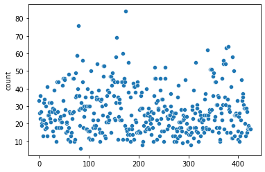

```python
sns.scatterplot(data=df["count"])
```

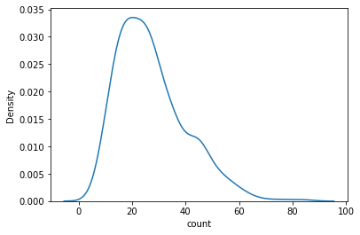

```python
sns.kdeplot(data=df["count"])
```

**Observational Note** Note that a lot of drop happens after 45. So, 45 words ought to be enough for highest number of words. Further analysis is needed.

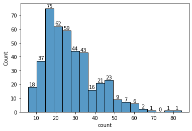

```python
ax=sns.histplot(df["count"])
for container in ax.containers:
    ax.bar_label(container)
```

**Observation**

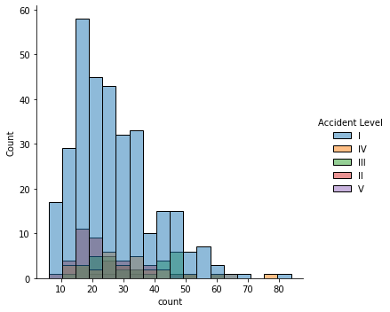

```python
sns.displot(data=df,x="count",hue="Accident Level")
# Gives us a guess whether word description length is anyway relation to assessed accident level and potential accident level
```

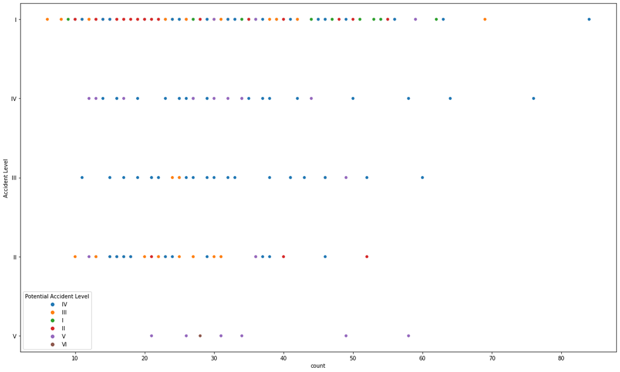

```python
plt.figure(figsize=(20,12))
sns.scatterplot(data=df,x="count",y="Accident Level",hue="Potential Accident Level")
plt.show()
```

**Observations**

It is to observe that since mean word description length is 27 words. That means anything less or more than that should be considered with doubt. It should be investigated whether the ability to guess properly and estimate the potential accident level can any way be because the description was less or more than required (there by confusing the model or not giving enough information to the model). If enough information is not present, our Chatbot should be able to identify and ask for more information from the user. To decide that we need to clear certain alternate Hypothesis and then move ahead.

**Note** Nowhere is it mentioned that the information is perfectly accurate. Hence, we can't take away the Observer's bias and also other errors in the data. If taken into consideration, this will enable the scalability of the model.

**Assumption**

Given the above, it is not clear whether there is any observer's bias. Hence, it's feasible to assume that one of the factors that might lead to escalation, or assessment of threat level might be improper description, directly leading to improper assessment of the Accident Level and directly contributing to the errors in Potential Threat level.

This can be converted to a Hypothesis and tested with appropriate probability chances if desired.

Restricting ourselves to 40 words length seems to be acceptable and comfortable, but before that we need to examine what are the other descriptions where it is less than the Quartile 1.

```python
df[df["count"]<df["count"].describe()["25%"]]
```

|  | Target | Text | tokens | count | count2 | diff | Countries | Local | Industry Sector | Accident Level | Potential Accident Level |
| --- | --- | --- | --- | --- | --- | --- | --- | --- | --- | --- | --- |
| 8 | I | Employee was sitting in the resting area at le... | [employe, sit, rest, area, level, rais, bore, ... | 13 | 29 | 16 | Country_02 | Local_02 | Mining | I | IV |
| 17 | I | Due to the overheating of 2 bars in row 5 of c... | [due, row, cell, spark, produc, reach, chief, ... | 13 | 44 | 31 | Country_01 | Local_06 | Metals | I | II |
| 28 | I | The worker carried out his work at level 2940,... | [the, worker, carri, work, level, stop, metal,... | 16 | 39 | 23 | Country_01 | Local_01 | Mining | I | IV |
| 29 | II | When using the griff wrench to unscrew the rod... | [when, griff, wrench, unscrew, rod, probe, key... | 13 | 27 | 14 | Country_02 | Local_07 | Mining | II | III |
| 34 | I | The employee was clearing the pipe when he tap... | [the, employe, clear, pipe, right, thumb, flan... | 10 | 19 | 9 | Country_02 | Local_05 | Metals | I | II |
| ... | ... | ... | ... | ... | ... | ... | ... | ... | ... | ... | ... |
| 403 | I | In circumstances that the worker prepared food... | [in, worker, prepar, food, electr, pot, lid, h... | 10 | 26 | 16 | Country_01 | Local_04 | Mining | I | II |
| 404 | I | In circumstances where the worker and two part... | [in, worker, two, killer, bomb, basket, team, ... | 13 | 35 | 22 | Country_01 | Local_04 | Mining | I | II |
| 407 | III | The employee performed insertion and adjustmen... | [the, employe, insert, adjust, joint, blind, f... | 15 | 46 | 31 | Country_02 | Local_02 | Mining | III | IV |
| 415 | I | Employee reports that by removing the zinc she... | [employe, remov, zinc, sheet, cathod, take, ea... | 13 | 31 | 18 | Country_02 | Local_05 | Metals | I | II |
| 417 | I | The technician was returning from his activiti... | [the, technician, bite, step, loos, rock, slop... | 15 | 38 | 23 | Country_03 | Local_10 | Others | I | IV |

87 rows × 11 columns

### Quartile 1 Outlier Examination

```python
outlier1=df[df["count"]<=df["count"].describe()["25%"]]  # Quartile 1 Outliers
```

```python
outlier1
```

|  | Target | Text | tokens | count | count2 | diff | Countries | Local | Industry Sector | Accident Level | Potential Accident Level |
| --- | --- | --- | --- | --- | --- | --- | --- | --- | --- | --- | --- |
| 8 | I | Employee was sitting in the resting area at le... | [employe, sit, rest, area, level, rais, bore, ... | 13 | 29 | 16 | Country_02 | Local_02 | Mining | I | IV |
| 12 | I | The collaborator reports that he was working i... | [the, collabor, work, cyclon, duct, door, tri,... | 17 | 45 | 28 | Country_02 | Local_05 | Metals | I | I |
| 17 | I | Due to the overheating of 2 bars in row 5 of c... | [due, row, cell, spark, produc, reach, chief, ... | 13 | 44 | 31 | Country_01 | Local_06 | Metals | I | II |
| 28 | I | The worker carried out his work at level 2940,... | [the, worker, carri, work, level, stop, metal,... | 16 | 39 | 23 | Country_01 | Local_01 | Mining | I | IV |
| 29 | II | When using the griff wrench to unscrew the rod... | [when, griff, wrench, unscrew, rod, probe, key... | 13 | 27 | 14 | Country_02 | Local_07 | Mining | II | III |
| ... | ... | ... | ... | ... | ... | ... | ... | ... | ... | ... | ... |
| 415 | I | Employee reports that by removing the zinc she... | [employe, remov, zinc, sheet, cathod, take, ea... | 13 | 31 | 18 | Country_02 | Local_05 | Metals | I | II |
| 417 | I | The technician was returning from his activiti... | [the, technician, bite, step, loos, rock, slop... | 15 | 38 | 23 | Country_03 | Local_10 | Others | I | IV |
| 419 | I | After maintenance on Boltec 03 at level 285 GT... | [after, mainten, level, mechan, oper, equip, e... | 17 | 48 | 31 | Country_02 | Local_02 | Mining | I | III |
| 423 | I | The Employee performed the activity of strippi... | [the, employe, activ, strip, cathod, sheet, ha... | 17 | 36 | 19 | Country_02 | Local_05 | Metals | I | II |
| 424 | I | At 10:00 a.m., when the assistant cleaned the ... | [at, assist, floor, modul, e, central, camp, s... | 17 | 41 | 24 | Country_01 | Local_04 | Mining | I | II |

107 rows × 11 columns

So many outliers. So, lets examine and see what they are.

```python
#for each in outlier1["Text"]:
#    print(each)
#    print("\n\n\n")
```

**Note** This will give us a plot and correlation between whether the less than average description of the incident, is in any way leading to higher accident levels. This can can be used to ask user to describe the incident in more detail, if our probabilities are not matching up to the threshold level. This will give us an assertion.

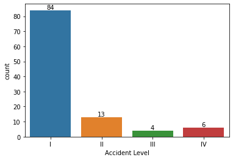

```python
ax=sns.countplot(x=outlier1["Accident Level"])
for container in ax.containers:
    ax.bar_label(container)
```

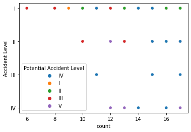

```python
sns.scatterplot(data=outlier1,x="count",y="Accident Level",hue="Potential Accident Level")
```

**Observation**

### Quartile 3 Outlier Examination

```python
outlier2=df[df["count"]>=df["count"].describe()["75%"]] # Quartile 3 Outliers
```

```python
outlier2
```

|  | Target | Text | tokens | count | count2 | diff | Countries | Local | Industry Sector | Accident Level | Potential Accident Level |
| --- | --- | --- | --- | --- | --- | --- | --- | --- | --- | --- | --- |
| 3 | I | Being 9:45 am. approximately in the Nv. 1880 C... | [be, approxim, personnel, task, unlock, machin... | 36 | 110 | 74 | Country_01 | Local_04 | Mining | I | I |
| 11 | I | While preparing the rice for the lunch of the ... | [while, rice, lunch, day, move, pot, weight, c... | 34 | 89 | 55 | Country_01 | Local_03 | Mining | I | IV |
| 16 | III | At Rp 050 of level 1620, in circumstances wher... | [at, level, compani, task, diamond, drill, inj... | 41 | 133 | 92 | Country_01 | Local_04 | Mining | III | IV |
| 31 | I | At level -1095 - Access 6 A2 - at times when t... | [at, level, access, time, engin, traine, verif... | 39 | 97 | 58 | Country_01 | Local_03 | Mining | I | II |
| 36 | I | During the withdrawal the Kelly bar (conductiv... | [dure, withdraw, kelli, bar, conduct, bar, len... | 44 | 114 | 70 | Country_01 | Local_01 | Mining | I | IV |
| ... | ... | ... | ... | ... | ... | ... | ... | ... | ... | ... | ... |
| 389 | V | When performing shotcrete casting for resane o... | [when, cast, cruis, approxim, oper, left, side... | 58 | 173 | 115 | Country_01 | Local_04 | Mining | V | V |
| 391 | IV | In the area of machine tools of the Maestran... | [in, area, mechan, injur, oper, bench, drill, ... | 50 | 142 | 92 | Country_01 | Local_03 | Mining | IV | IV |
| 406 | I | In circumstances that the driver of the plate ... | [in, driver, plate, truck, went, plant, enter,... | 45 | 130 | 85 | Country_01 | Local_01 | Mining | I | IV |
| 409 | II | When the Master additive was taken from the AF... | [when, master, addit, taken, licens, plate, to... | 37 | 99 | 62 | Country_01 | Local_03 | Mining | II | IV |
| 410 | IV | Being 9:40 a.m. The driver of the AEQ-819 plat... | [be, the, driver, plate, dump, truck, ton, hea... | 35 | 91 | 56 | Country_01 | Local_04 | Mining | IV | IV |

116 rows × 11 columns

```python
#for each in outlier2["Text"]:
#    print(each)
#    print("\n\n\n")
```

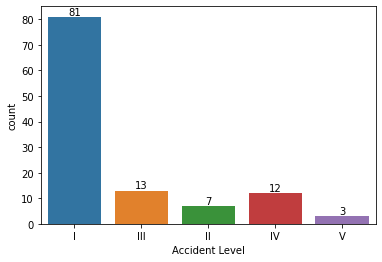

```python
ax=sns.countplot(x=outlier2["Accident Level"])
for container in ax.containers:
    ax.bar_label(container)
```

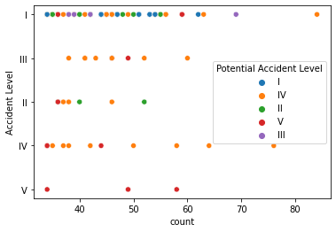

```python
sns.scatterplot(data=outlier2,x="count",y="Accident Level",hue="Potential Accident Level")
```

**Observation**

It is to be noted that there are not a lot of data points for us to accurately evaluate whether the length of description has got anything to do at all with the outliers of the third Quartile. Though there are more outliers on this front than Quartile 1, the difference is extremely small and it is still part of the normal distribution.

### Inter-Quartile Outlier Examination

```python
Q1=set(df[df["count"]<=df["count"].describe()["75%"]].index)
Q3=set(df[df["count"]>=df["count"].describe()["25%"]].index)
Q1.intersection(Q3)

inlier=df.loc[Q1.intersection(Q3)]
```

```python
inlier
```

|  | Target | Text | tokens | count | count2 | diff | Countries | Local | Industry Sector | Accident Level | Potential Accident Level |
| --- | --- | --- | --- | --- | --- | --- | --- | --- | --- | --- | --- |
| 0 | I | While removing the drill rod of the Jumbo 08 f... | [while, remov, drill, rod, jumbo, mainten, sup... | 33 | 84 | 51 | Country_01 | Local_01 | Mining | I | IV |
| 1 | I | During the activation of a sodium sulphide pum... | [dure, activ, sodium, sulphid, pump, pipe, unc... | 26 | 59 | 33 | Country_02 | Local_02 | Mining | I | IV |
| 2 | I | In the sub-station MILPO located at level +170... | [in, level, collabor, excav, work, pick, hand,... | 23 | 62 | 39 | Country_01 | Local_03 | Mining | I | III |
| 4 | IV | Approximately at 11:45 a.m. in circumstances t... | [approxim, mechan, group, leader, eric, three,... | 27 | 100 | 73 | Country_01 | Local_04 | Mining | IV | IV |
| 5 | I | During the unloading operation of the ustulado... | [dure, oper, bag, need, unclog, discharg, mout... | 20 | 55 | 35 | Country_02 | Local_05 | Metals | I | III |
| ... | ... | ... | ... | ... | ... | ... | ... | ... | ... | ... | ... |
| 420 | I | Being approximately 5:00 a.m. approximately, w... | [be, approxim, approxim, lift, kelli, toward, ... | 18 | 41 | 23 | Country_01 | Local_04 | Mining | I | III |
| 421 | I | The collaborator moved from the infrastructure... | [the, collabor, infrastructur, offic, julio, p... | 19 | 43 | 24 | Country_01 | Local_03 | Mining | I | II |
| 422 | I | During the environmental monitoring activity i... | [dure, environment, activ, area, employe, swar... | 18 | 49 | 31 | Country_02 | Local_09 | Metals | I | II |
| 423 | I | The Employee performed the activity of strippi... | [the, employe, activ, strip, cathod, sheet, ha... | 17 | 36 | 19 | Country_02 | Local_05 | Metals | I | II |
| 424 | I | At 10:00 a.m., when the assistant cleaned the ... | [at, assist, floor, modul, e, central, camp, s... | 17 | 41 | 24 | Country_01 | Local_04 | Mining | I | II |

232 rows × 11 columns

```python
#for each in inliers["Text"]:
#    print(each)
#    print("\n\n\n")
```

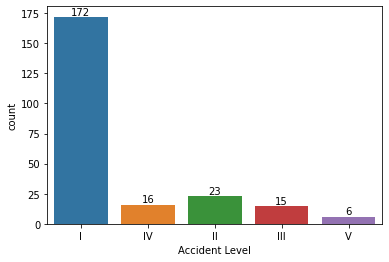

```python
ax=sns.countplot(x=inlier["Accident Level"])
for container in ax.containers:
    ax.bar_label(container)
```

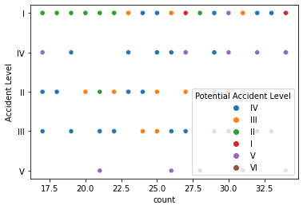

```python
sns.scatterplot(data=inlier,x="count",y="Accident Level",hue="Potential Accident Level")
```

**Observation**

Even for the Inliners, the data is pretty normally distributed with data not beating or producing anything odd. The progression also from Accident Level 1 assessment and stayed at that particular accident level or further can be assessed without much influence created because of the length of the description given.

It is pretty normally distributed.

**Inferences and Propositions**

It can be seen that the length of description has got nothing to do, presupposedly with the kind of threat assessment level, atleast for the given data. For any more analysis, we need a humungous data to decipher any particular pattern in all this.

**Hypothesis**

1. The length of description used for any particular event has got little influence on the outcome of the prediction and assessment of any particular Accident Level.

**Inference**

It needs to be seen whether a Country has more influence on the kind of langauge and description of the data involved. Hence, we need to take a step ahead and see the countrywise description on how the average number of words used is and how it is distributed.

**Warning** The data is heavily distorted in this regard since some countries are over represented. Hence, deciphering any actionable intelligence on this regard is not feasible.

# Description Analysis based on Country

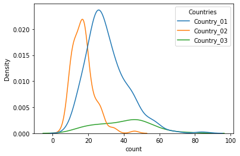

```python
sns.kdeplot(data=df,x="count",hue="Countries")
```

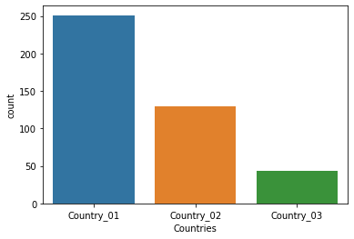

```python
sns.countplot(data=df,x="Countries")
```

**Observations & Inference**

```python
lest_desc=df["count"].sort_values()[:5].index # The lowest description texts
most_desc=df["count"].sort_values()[-5:].index # The Highest description texts
```

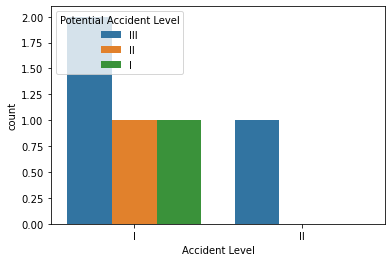

```python
sns.countplot(data=df.loc[lest_desc],x="Accident Level",hue="Potential Accident Level")
```

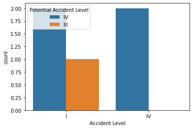

```python
sns.countplot(data=df.loc[most_desc],x="Accident Level",hue="Potential Accident Level")
```

As described earlier, there is seemingly no relationship between the description detail of the incident and the assessed accident level. Even if there is, there is simply no information on hand to back it up.

A Final look at those top 5 Most and least described events.

```python
for each in df.loc[lest_desc]["Text"]:
    print(each)
    print("\n\n")
```

```
Employee reports that when handling the air conditioning pressed the 2nd right chirodactilo causing a contusion.



the check list of the area of the survey the operator slipped in the foliage of the leucenas and fell.



Employee was transiting the GRS area when he came to slip, suffering a twist in his left knee.



During the preparation for the scaffolding activity, the employee was loading the pieces to the designated place where he had his finger pressed between the metal pieces that were being moved.



The employee of partner company GR reports that she was cutting watermelon when she injured her 2nd chirodactilo of the left hand with the knife.
```

```python
for each in df.loc[most_desc]["Text"]:
    print(each)
    print("\n\n")
```

```
On 04/19/2017, the employee de Lima da Silva was composing the team of opening of bite to survey of IP. The team consisted of one mining technician and three assistants. When was moving in the bite he touched his left foot on a stump of Tucum that was on the ground covered with dry leaves of vegetat…



Performing the cleaning of material (Mineral) that accumulates between the steel plate and the concrete base on which it rests; As shown in the photograph (steel plate thickness = 1/2 in.), in order to complete this cleaning, the workers decide to weld on the steel plate a support eyelet type and at…



When the mechanical technician proceeded to perform the maintenance of motor supports of a tipper, he decided to bring a wooden block, for which he moved to the temporary storage of materials - located at 10 m. of the tipper - in circumstances in which he sought the cue; the camera of a tire burst s…



When performing the sleeve removal maneuver, when the hole was 600 meters deep, General da Silva pressed only one side of the locking nut of the rods, which together with the jack, holds the entire weight of the rods in the maneuver. As the locking procedure was not effective, the weight of the rods…



At level 3490 gallery 239, during the holding activity with the Bolter equipment No. 24, the operator performs the drilling of the first hole to support the right gable; When the 7-foot-deep drill was about to end, the drill rod breaks, leaving the threads inside the drilling machine's shank; the op…
```

# Interim Remarks Before Model building

1. It is Observed that the length of the description doesn't translate at all into the possible misjudgement for a country.
2. However, it is to be noted that studying the description given for proper formatting, and verifying threshold paramters of the model, will have to be integrated into the model while training phase itself. So, for example if the bot is used for anything else other than its intended purpose, it should simply choose not to respond, or politely deny the request.
3. It has to be taken care that when description is given by the user it is enough : assurance that the description is enough to make a proper guess with proper probability becomes extremely important. Hence, a mechanism of asking for more detailed description if the given input is insufficient for probability par score is required. Hence the implementation is to be in that regard.
4. Other ideas like Accent detection, Named entity recognition to identify the Nouns and from there guessing a country etc. have been deemed impossible with the scarcity of the data at hand.

# Model Building

```python
tf.__version__
```

```
'2.6.0'
```

```python
df=pd.read_json("master_df.json")
```

```python
df
```

|  | Target | Text | tokens | count | count2 | diff |
| --- | --- | --- | --- | --- | --- | --- |
| 0 | I | While removing the drill rod of the Jumbo 08 f... | [while, removing, drill, rod, jumbo, maintenan... | 33 | 84 | 51 |
| 1 | I | During the activation of a sodium sulphide pum... | [during, activation, sodium, sulphide, pump, p... | 26 | 59 | 33 |
| 2 | I | In the sub-station MILPO located at level +170... | [in, level, collaborator, excavation, work, pi... | 23 | 62 | 39 |
| 3 | I | Being 9:45 am. approximately in the Nv. 1880 C... | [being, approximately, personnel, task, unlock... | 36 | 110 | 74 |
| 4 | IV | Approximately at 11:45 a.m. in circumstances t... | [approximately, mechanics, group, leader, eric... | 27 | 100 | 73 |
| ... | ... | ... | ... | ... | ... | ... |
| 420 | I | Being approximately 5:00 a.m. approximately, w... | [being, approximately, approximately, lifting,... | 18 | 41 | 23 |
| 421 | I | The collaborator moved from the infrastructure... | [the, collaborator, infrastructure, office, ju... | 19 | 43 | 24 |
| 422 | I | During the environmental monitoring activity i... | [during, environmental, activity, area, employ... | 18 | 49 | 31 |
| 423 | I | The Employee performed the activity of strippi... | [the, employee, activity, stripping, cathode, ... | 17 | 36 | 19 |
| 424 | I | At 10:00 a.m., when the assistant cleaned the ... | [at, assistant, floor, module, e, central, cam... | 17 | 41 | 24 |

425 rows × 6 columns

```python
df_main=df[["Target","tokens"]]
```

```python
df_main["tokens"]
```

```
0      [while, removing, drill, rod, jumbo, maintenan...
1      [during, activation, sodium, sulphide, pump, p...
2      [in, level, collaborator, excavation, work, pi...
3      [being, approximately, personnel, task, unlock...
4      [approximately, mechanics, group, leader, eric...
                             ...
420    [being, approximately, approximately, lifting,...
421    [the, collaborator, infrastructure, office, ju...
422    [during, environmental, activity, area, employ...
423    [the, employee, activity, stripping, cathode, ...
424    [at, assistant, floor, module, e, central, cam...
Name: tokens, Length: 425, dtype: object
```

```python
df_main["Target"]
```

```
0       I
1       I
2       I
3       I
4      IV
       ..
420     I
421     I
422     I
423     I
424     I
Name: Target, Length: 425, dtype: object
```

```python
Maximum_desc_length=45 # This is a Tunable parameters based on the Scalability of the model
Embedding_dimensions=25 # This is a Tunable Hyper-parameter based on the Scalability of the model
```

## Creating Word Vocabulary

This can always be and should be updated based on the scalability and the data at hand. Hoping that we continue with the model we already have.

```python
from nltk.util import flatten
vocab=set(flatten(list(df_main["tokens"])))
```

```python
vocab_dict={word:key+1 for key,word in enumerate(vocab)} #0 is used for padding
```

```python
vocab_dict.update({0:0})
```

```python
pd.Series(vocab_dict)
```

```
rig                     1
frontally               2
electrometallurgy       3
triangular              4
displacement            5
                     ...
electrolyte          1971
central              1972
progress             1973
slide                1974
0                       0
Length: 1975, dtype: int64
```

```python
def word2idx(text_list,vocabulary=vocab_dict):
    import numpy as np
    index=[]
    for each in text_list:
        index.append(vocabulary[each])
    return np.array(index)
```

```python
#dview.push(dict(vocabulary=vocab_dict))
```

[output not shown]

```python
#X=dview.map_sync(word2idx,df_main["tokens"])
X=df_main["tokens"].apply(word2idx)
```

```python
#X
```

```python
from tensorflow.keras import Sequential
from tensorflow.keras.layers import Dense, Embedding, LSTM, SpatialDropout1D
from tensorflow.keras.preprocessing.sequence import pad_sequences
from tensorflow.keras.layers import Input
maxlen=Maximum_desc_length
```

```python
X=pad_sequences(X,maxlen=maxlen) # This is the perfectly padded Sequence for Analysis.
```

```python
X
```

```
array([[   0,    0,    0, ...,  184,  736, 1777],
       [   0,    0,    0, ...,  576, 1909,  346],
       [   0,    0,    0, ...,  271,  580,   81],
       ...,
       [   0,    0,    0, ..., 1628, 1702,  861],
       [   0,    0,    0, ..., 1628, 1702,  861],
       [   0,    0,    0, ...,  806,  708,   81]])
```

```python
X.shape[1]
```

```
45
```

```python
levels_dict={"I":1,"II":2,"III":3,"IV":4,"V":5,"VI":6}

y=pd.get_dummies(df_main["Target"]) # This is out Target
#y["VI"]=np.zeros(y.shape[0]).astype("int")
y
```

|  | I | II | III | IV | V |
| --- | --- | --- | --- | --- | --- |
| 0 | 1 | 0 | 0 | 0 | 0 |
| 1 | 1 | 0 | 0 | 0 | 0 |
| 2 | 1 | 0 | 0 | 0 | 0 |
| 3 | 1 | 0 | 0 | 0 | 0 |
| 4 | 0 | 0 | 0 | 1 | 0 |
| ... | ... | ... | ... | ... | ... |
| 420 | 1 | 0 | 0 | 0 | 0 |
| 421 | 1 | 0 | 0 | 0 | 0 |
| 422 | 1 | 0 | 0 | 0 | 0 |
| 423 | 1 | 0 | 0 | 0 | 0 |
| 424 | 1 | 0 | 0 | 0 | 0 |

425 rows × 5 columns

```python
Model_measures=[pd.DataFrame()]
##########################################################
# Function that adds information about each Model
###########################################################
def add_model_params(hist,model_name):
    h=hist.history
    h.update({"model":model_name})
    Model_measures.append(pd.DataFrame(h))
    ax1=plt.subplot(121)
    ax1=plt.title("Accuracy Vs Epochs")
    ax1=plt.plot(hist.epoch,h["accuracy"],label="train") # Epoch Vs Accuracy. Notice it is fading to pay off after 6 epochs but rising later on
    ax1=plt.plot(hist.epoch,h["val_accuracy"],label="validation")
    ### Loss Vs Accuracy for scope of application of the model
    ax2=plt.subplot(122)
    ax2=plt.title("Loss vs Accuracy")
    ax2=plt.plot(h["loss"],h["accuracy"],label="train") # Loss Vs Accuracy plot (Not much in this)
    ax2=plt.plot(h["val_loss"],h["val_accuracy"],label="validation")
    plt.legend()
    plt.show()

#############################################################
# End of the Function
###############################################################
```

```python
vocab_size2=len(vocab_dict)
embedding_dimensions= 50
length_of_sequence=X.shape[1]
lstm_out = 48
# You can change these parameters and manipulate them as per wish here itself. To Compare across models, these parameters are fixed.
```

```python
from tensorflow.keras.models import Sequential,Model
from tensorflow.keras.layers import Dense, Embedding, LSTM, SpatialDropout1D, Bidirectional, Attention, Conv1D, GlobalAveragePooling1D, Flatten, Dropout

from keras_self_attention import SeqSelfAttention # Ready-made Self-Attention Model
```

## Simple LSTM Model

```python
embedding_layer=Embedding (vocab_size2,
                           embedding_dimensions,
                           trainable=True,
                          input_length=length_of_sequence)

input_sequences=Input(shape=(None,),dtype="int64")
k=embedding_layer(input_sequences)
#k= tf.keras.layers.Conv1D(filters=100,kernel_size=4,padding='same')(k)
#k=tf.keras.layers.GlobalAveragePooling1D()(k)
#k=SpatialDropout1D(0.4)(k)
#k=Bidirectional(LSTM(lstm_out, dropout=0.2, recurrent_dropout=0.2,return_sequences=True))(k)
k=LSTM(lstm_out, dropout=0.2, recurrent_dropout=0.2)(k)
k=Dense(12,activation='relu',kernel_regularizer=tf.keras.regularizers.L1(l1=0.01))(k)
outputs=Dense(5,activation="softmax",kernel_regularizer=tf.keras.regularizers.L2(l2=0.01))(k)
model=Model(inputs=input_sequences,outputs=outputs,name="Simple_LSTM")
model.compile(loss = 'categorical_crossentropy', optimizer='adam',metrics = ['accuracy'])
print(model.summary())

history=model.fit(X,y,validation_split=0.08,epochs=40,batch_size=8)
```

```
WARNING:tensorflow:Layer lstm will not use cuDNN kernels since it doesn't meet the criteria. It will use a generic GPU kernel as fallback when running on GPU.
Model: "Simple_LSTM"
_________________________________________________________________
Layer (type)                 Output Shape              Param #
=================================================================
input_1 (InputLayer)         [(None, None)]            0
_________________________________________________________________
embedding (Embedding)        (None, None, 50)          98750
_________________________________________________________________
lstm (LSTM)                  (None, 48)                19008
_________________________________________________________________
dense (Dense)                (None, 12)                588
_________________________________________________________________
dense_1 (Dense)              (None, 5)                 65
=================================================================
Total params: 118,411
Trainable params: 118,411
Non-trainable params: 0
_________________________________________________________________
None
```

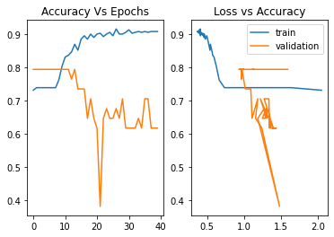

```python
add_model_params(history,"Simple LSTM")
```

**Note an Important Point here**

The Validation accuracy is not steady. It is jumping all over the place unlike the Training accuracy. It is a very strong indicator that the data is not enough, and the samples are not normally or randomly distributed to be able to judge something.

## Simple Bidirectional LSTM Model

```python
model2=Sequential()
model2.add(Embedding(vocab_size2,embedding_dimensions,trainable=True,input_length=length_of_sequence))
model2.add(SpatialDropout1D(0.2))
model2.add(Bidirectional(LSTM(lstm_out, dropout=0.2, return_sequences=True, recurrent_dropout=0.2)))
model2.add(LSTM(48, dropout=0.2,unroll=True,recurrent_dropout=0.2))
model2.add(Dense(12,activation='relu',kernel_regularizer=tf.keras.regularizers.L1(0.01)))
model2.add(Dense(5,activation="softmax",kernel_regularizer=tf.keras.regularizers.L1L2(l1=0.01, l2=0.01)))
model2.compile(loss = 'categorical_crossentropy', optimizer='adam',metrics = ['accuracy'])
print(model2.summary())
history2=model2.fit(X,y,validation_split=0.1,batch_size=8,epochs=40)
```

```
WARNING:tensorflow:Layer lstm_1 will not use cuDNN kernels since it doesn't meet the criteria. It will use a generic GPU kernel as fallback when running on GPU.
WARNING:tensorflow:Layer lstm_1 will not use cuDNN kernels since it doesn't meet the criteria. It will use a generic GPU kernel as fallback when running on GPU.
WARNING:tensorflow:Layer lstm_1 will not use cuDNN kernels since it doesn't meet the criteria. It will use a generic GPU kernel as fallback when running on GPU.
WARNING:tensorflow:Layer lstm_2 will not use cuDNN kernels since it doesn't meet the criteria. It will use a generic GPU kernel as fallback when running on GPU.
Model: "sequential"
_________________________________________________________________
Layer (type)                 Output Shape              Param #
=================================================================
embedding_1 (Embedding)      (None, 45, 50)            98750
_________________________________________________________________
spatial_dropout1d (SpatialDr (None, 45, 50)            0
_________________________________________________________________
bidirectional (Bidirectional (None, 45, 96)            38016
_________________________________________________________________
lstm_2 (LSTM)                (None, 48)                27840
_________________________________________________________________
dense_2 (Dense)              (None, 12)                588
_________________________________________________________________
dense_3 (Dense)              (None, 5)                 65
=================================================================
Total params: 165,259
Trainable params: 165,259
Non-trainable params: 0
_________________________________________________________________
None
```

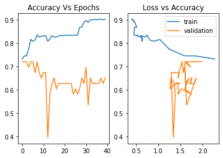

```python
add_model_params(history2,"Simple BiLSTM")
```

## Self - Attention with simple LSTM

```python
#
model3=Sequential()
model3.add(Embedding(vocab_size2,embedding_dimensions,trainable=True,input_length=length_of_sequence))
model3.add(SpatialDropout1D(0.2))
model3.add(SeqSelfAttention(attention_width=15, attention_activation='sigmoid'))
#model3.add(Bidirectional(LSTM(lstm_out, dropout=0.2, return_sequences=True, recurrent_dropout=0.2)))
#model3.add(SeqSelfAttention(attention_width=15, attention_activation='sigmoid'))
model3.add(LSTM(45, dropout=0.2,recurrent_dropout=0.2))
#model3.add(SeqSelfAttention(attention_width=15, attention_activation='sigmoid'))
model3.add(Dense(12,activation='relu',kernel_regularizer=tf.keras.regularizers.L1(0.01)))
model3.add(Dense(5,activation="softmax",kernel_regularizer=tf.keras.regularizers.L1L2(l1=0.01, l2=0.01)))
model3.compile(loss = 'categorical_crossentropy', optimizer='adam',metrics = ['accuracy'])
print(model3.summary())
history3=model3.fit(X,y,validation_split=0.1,batch_size=5,epochs=40)
```

```
WARNING:tensorflow:Layer lstm_3 will not use cuDNN kernels since it doesn't meet the criteria. It will use a generic GPU kernel as fallback when running on GPU.
Model: "sequential_1"
_________________________________________________________________
Layer (type)                 Output Shape              Param #
=================================================================
embedding_2 (Embedding)      (None, 45, 50)            98750
_________________________________________________________________
spatial_dropout1d_1 (Spatial (None, 45, 50)            0
_________________________________________________________________
seq_self_attention (SeqSelfA (None, None, 50)          3265
_________________________________________________________________
lstm_3 (LSTM)                (None, 45)                17280
_________________________________________________________________
dense_4 (Dense)              (None, 12)                552
_________________________________________________________________
dense_5 (Dense)              (None, 5)                 65
=================================================================
Total params: 119,912
Trainable params: 119,912
Non-trainable params: 0
_________________________________________________________________
None
```

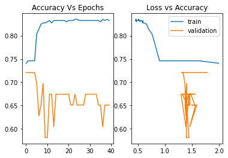

```python
add_model_params(history3,"Attenion LSTM" )
```

**Note**

Note the same thing again. There is no specific pattern, highly indicating that there is a complete mismatch between the training data and the validation data, since it is much more susceptible to the information variations and non-normalized data. Thus indicating that splitting the data is causing irreperable damage and loss of valuable information from the training data set.

## Self-Attention with Convolution, LSTM and Bidirectional

```python
m=Sequential()
m.add(Embedding (vocab_size2,
                           embedding_dimensions,
                           trainable=True,
                          input_length=length_of_sequence))

#input_sequences=Input(shape=(None,),dtype="int32")
#k=embedding_layer(input_sequences)
m.add(SpatialDropout1D(0.2))
m.add(Conv1D(filters=200,kernel_size=4,padding='same'))
m.add(Dropout(0.2))
#k=Bidirectional(LSTM(lstm_out, dropout=0.2, recurrent_dropout=0.2,return_sequences=True))(k)
m.add(Bidirectional(LSTM(lstm_out, dropout=0.2, recurrent_dropout=0.2,return_sequences=True)))
m.add(SeqSelfAttention(attention_width=10, attention_activation='sigmoid'))
#m.add(Flatten())
m.add(LSTM(lstm_out, dropout=0.2, recurrent_dropout=0.4))
#m.add(Dense(12,activation='relu',kernel_regularizer=tf.keras.regularizers.L1(l1=0.01)))
#m.add(Flatten())
m.add(Dense(5,activation="softmax",kernel_regularizer=tf.keras.regularizers.L2(l2=0.01)))
#m.add(Flatten())
#model=Model(inputs=input_sequences,outputs=outputs)
m.compile(loss = 'categorical_crossentropy', optimizer='adam',metrics = ['accuracy'])
print(m.summary())

history5=m.fit(X,y,validation_split=0.1,batch_size=8,epochs=40)
```

```
WARNING:tensorflow:Layer lstm_4 will not use cuDNN kernels since it doesn't meet the criteria. It will use a generic GPU kernel as fallback when running on GPU.
WARNING:tensorflow:Layer lstm_4 will not use cuDNN kernels since it doesn't meet the criteria. It will use a generic GPU kernel as fallback when running on GPU.
WARNING:tensorflow:Layer lstm_4 will not use cuDNN kernels since it doesn't meet the criteria. It will use a generic GPU kernel as fallback when running on GPU.
WARNING:tensorflow:Layer lstm_5 will not use cuDNN kernels since it doesn't meet the criteria. It will use a generic GPU kernel as fallback when running on GPU.
Model: "sequential_2"
_________________________________________________________________
Layer (type)                 Output Shape              Param #
=================================================================
embedding_3 (Embedding)      (None, 45, 50)            98750
_________________________________________________________________
spatial_dropout1d_2 (Spatial (None, 45, 50)            0
_________________________________________________________________
conv1d (Conv1D)              (None, 45, 200)           40200
_________________________________________________________________
dropout (Dropout)            (None, 45, 200)           0
_________________________________________________________________
bidirectional_1 (Bidirection (None, 45, 96)            95616
_________________________________________________________________
seq_self_attention_1 (SeqSel (None, None, 96)          6209
_________________________________________________________________
lstm_5 (LSTM)                (None, 48)                27840
_________________________________________________________________
dense_6 (Dense)              (None, 5)                 245
=================================================================
Total params: 268,860
Trainable params: 268,860
Non-trainable params: 0
_________________________________________________________________
None
```

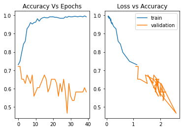

```python
add_model_params(history5,"Attenion Conv BiLSTM")
```

## Self- Attention from Tensorflow - Just for Testing

```python
embedding_layer=Embedding (vocab_size2,
                           embedding_dimensions,
                           trainable=True,
                          input_length=length_of_sequence)

input_sequences=Input(shape=(None,),dtype="int64")
k=embedding_layer(input_sequences)

#k= tf.keras.layers.Conv1D(filters=100,kernel_size=4,padding='same')(k)

#k=SpatialDropout1D(0.4)(k)
k=Bidirectional(LSTM(lstm_out, dropout=0.2, recurrent_dropout=0.2,return_sequences=True))(k)
#k=GlobalAveragePooling1D()(k)
k=Attention(use_scale=True)([k,k]) # Direct from tensorflow Layering
k=LSTM(lstm_out, dropout=0.2, recurrent_dropout=0.2)(k)
k=Dense(12,activation='relu',kernel_regularizer=tf.keras.regularizers.L1(l1=0.01))(k)
outputs=Dense(5,activation="softmax",kernel_regularizer=tf.keras.regularizers.L2(l2=0.01))(k)
model=Model(inputs=input_sequences,outputs=outputs)
model.compile(loss = 'categorical_crossentropy', optimizer='adam',metrics = ['accuracy'])
print(model.summary())
model.fit(X,y,validation_split=0.1,batch_size=8,epochs=40)
```

```
WARNING:tensorflow:Layer lstm_6 will not use cuDNN kernels since it doesn't meet the criteria. It will use a generic GPU kernel as fallback when running on GPU.
WARNING:tensorflow:Layer lstm_6 will not use cuDNN kernels since it doesn't meet the criteria. It will use a generic GPU kernel as fallback when running on GPU.
WARNING:tensorflow:Layer lstm_6 will not use cuDNN kernels since it doesn't meet the criteria. It will use a generic GPU kernel as fallback when running on GPU.
WARNING:tensorflow:Layer lstm_7 will not use cuDNN kernels since it doesn't meet the criteria. It will use a generic GPU kernel as fallback when running on GPU.
Model: "model_1"
__________________________________________________________________________________________________
Layer (type)                    Output Shape         Param #     Connected to
==================================================================================================
input_2 (InputLayer)            [(None, None)]       0
__________________________________________________________________________________________________
embedding_4 (Embedding)         (None, None, 50)     98750       input_2[0][0]
__________________________________________________________________________________________________
bidirectional_2 (Bidirectional) (None, None, 96)     38016       embedding_4[0][0]
__________________________________________________________________________________________________
attention (Attention)           (None, None, 96)     1           bidirectional_2[0][0]
                                                                 bidirectional_2[0][0]
__________________________________________________________________________________________________
lstm_7 (LSTM)                   (None, 48)           27840       attention[0][0]
__________________________________________________________________________________________________
dense_7 (Dense)                 (None, 12)           588         lstm_7[0][0]
__________________________________________________________________________________________________
dense_8 (Dense)                 (None, 5)            65          dense_7[0][0]
==================================================================================================
Total params: 165,260
Trainable params: 165,260
Non-trainable params: 0
__________________________________________________________________________________________________
None
```

```
<keras.callbacks.History at 0x2087810c9d0>
```

```python
#add model paramters
```

## Multi-Headed Attention - From Tensorflow

```python
from tensorflow.keras.layers import MultiHeadAttention
##
#
#
layer=MultiHeadAttention(num_heads=3, key_dim=3)
#
#
embedding_layer=Embedding (vocab_size2,
                           embedding_dimensions,
                           trainable=True,
                          input_length=length_of_sequence)

input_sequences=Input(shape=(None,),dtype="int64")
k=embedding_layer(input_sequences)

k= Conv1D(filters=100,kernel_size=4,padding='same')(k)

#k=SpatialDropout1D(0.4)(k)
#k=Bidirectional(LSTM(lstm_out, dropout=0.2, recurrent_dropout=0.2,return_sequences=True))(k)
#k=GlobalAveragePooling1D()(k)
k=layer(k,k)
#k=Attention(use_scale=True)([k,k]) # Direct from tensorflow Layering
k=LSTM(lstm_out, dropout=0.2, recurrent_dropout=0.2)(k)
k=Dense(12,activation='relu',kernel_regularizer=tf.keras.regularizers.L1(l1=0.01))(k)
outputs=Dense(5,activation="softmax",kernel_regularizer=tf.keras.regularizers.L2(l2=0.01))(k)
model=Model(inputs=input_sequences,outputs=outputs)
model.compile(loss = 'categorical_crossentropy', optimizer='adam',metrics = ['accuracy'])
print(model.summary())
```

```
WARNING:tensorflow:Layer lstm_8 will not use cuDNN kernels since it doesn't meet the criteria. It will use a generic GPU kernel as fallback when running on GPU.
Model: "model_2"
__________________________________________________________________________________________________
Layer (type)                    Output Shape         Param #     Connected to
==================================================================================================
input_3 (InputLayer)            [(None, None)]       0
__________________________________________________________________________________________________
embedding_5 (Embedding)         (None, None, 50)     98750       input_3[0][0]
__________________________________________________________________________________________________
conv1d_1 (Conv1D)               (None, None, 100)    20100       embedding_5[0][0]
__________________________________________________________________________________________________
multi_head_attention (MultiHead (None, None, 100)    3727        conv1d_1[0][0]
                                                                 conv1d_1[0][0]
__________________________________________________________________________________________________
lstm_8 (LSTM)                   (None, 48)           28608       multi_head_attention[0][0]
__________________________________________________________________________________________________
dense_9 (Dense)                 (None, 12)           588         lstm_8[0][0]
__________________________________________________________________________________________________
dense_10 (Dense)                (None, 5)            65          dense_9[0][0]
==================================================================================================
Total params: 151,838
Trainable params: 151,838
Non-trainable params: 0
__________________________________________________________________________________________________
None
```

```python
history4=model.fit(X,y,validation_split=0.1,batch_size=8,epochs=40)
```

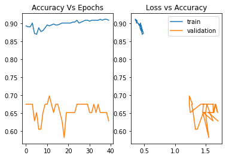

```python
add_model_params(history4,"Multi-Head Attention")
```

## Transformer for Seq2Seq Models with Attention (Not Working)

Got this from the Resource mentioned here.

https://towardsdatascience.com/create-your-own-custom-attention-layer-understand-all-flavours-2201b5e8be9e

```python
class peel_the_layer(tf.keras.layers.Layer):
    def __init__(self):
        ##Nothing special to be done here
        super(peel_the_layer, self).__init__()

    def build(self, input_shape):
        ##Define the shape of the weights and bias in this layer
        ##This is a 1 unit layer.
        units=1
        ##last index of the input_shape is the number of dimensions of the prev
        ##RNN layer. last but 1 index is the num of timesteps
        self.w=self.add_weight(name="att_weights", shape=(input_shape[-1], units), initializer="normal") #name property is useful for avoiding RuntimeError: Unable to create link.
        self.b=self.add_weight(name="att_bias", shape=(input_shape[-2], units), initializer="zeros")
        super(peel_the_layer,self).build(input_shape)

    def call(self, x):
        ##x is the input tensor..each word that needs to be attended to
        ##Below is the main processing done during training
        ##K is the Keras Backend import
        e = K.tanh(K.dot(x,self.w)+self.b)
        a = K.softmax(e, axis=1)
        output = x*a

        ##return the ouputs. 'a' is the set of attention weights
        ##the second variable is the 'attention adjusted o/p state' or context
        return K.sum(output, axis=1)
```

```python
embedding_layer=Embedding (vocab_size2,
                           embedding_dimensions,
                           trainable=True,
                          input_length=length_of_sequence)

input_sequences=Input(shape=(None,),dtype="int64")
k=embedding_layer(input_sequences)

#k= tf.keras.layers.Conv1D(filters=100,kernel_size=4,padding='same')(k)

k=SpatialDropout1D(0.4)(k)
#k=Bidirectional(LSTM(lstm_out, dropout=0.2, recurrent_dropout=0.2,return_sequences=True))(k)
k=LSTM(lstm_out, dropout=0.2, recurrent_dropout=0.2)(k)
k = peel_the_layer()(k)
k=Dense(12,activation='relu',kernel_regularizer=tf.keras.regularizers.L1(l1=0.01))(k)
outputs=Dense(5,activation="softmax",kernel_regularizer=tf.keras.regularizers.L2(l2=0.01))(k)
model=Model(inputs=input_sequences,outputs=outputs)
model.compile(loss = 'categorical_crossentropy', optimizer='adam',metrics = ['accuracy'])
print(model.summary())
```

```
WARNING:tensorflow:Layer lstm_9 will not use cuDNN kernels since it doesn't meet the criteria. It will use a generic GPU kernel as fallback when running on GPU.
```

[output not shown]

[output cut: 45 more lines]

[output not shown]

```python
history6=model.fit(X,y,validation_split=0.1,batch_size=8,epochs=40)
```

**Inference and Hypothesis**

It is to be noted that the datasets that are limited by the diversity in them in combination with less frequency of any given occurrence will fall into the trap of vanishing gradient (i.e. becoming an outlier), in any given dataset. Hence, when we have limited amount of data to which we can fit our model, it is better to choose the model that is more equalized across the dataset i.e. producing the same results irrespective of the size of the training set and validation set. It is expected to produce the same results, in case of any future increase in the data points in future.

**Conclusion**

Results here are clearly visible as to why and how our hypothesis indicates and what is the final model chosen by us. The reasons behind them are declared and studied at every step.

# Iteration 1

## Comments

**Observations**

1. Model is refusing to learn beyond a certain point. So, it means that saturation point for the model has reached. So, there needs some experimentation w.r.t hyper-parameters or the model itself has to change.
2. It is noticed that rate of initial learning is extremely fast, most probably indicating that Model will most likely be an overfit for the kind of data at hand at present and future scope of data. This implies model needs to be a lot more simplified in the sense that paramters, LSTM layers (as guessed before) will have to be reduced and attempted again.
3. As we have seen before certain words are holding special interest, so Attention mechanism can be deployed here for testing and evaluating purposes.

## Preliminary Analysis of Models

# Iteration 3 & 4

## Analysis

```python
Model_measures=[]
Model_measures.append(pd.DataFrame(history.history))
```

```python
Model_measures.append(pd.DataFrame(history2.history))
Model_measures.append(pd.DataFrame(history3.history))
Model_measures.append(pd.DataFrame(history4.history))
Model_measures.append(pd.DataFrame(history5.history))
#Model_measures.append(pd.DataFrame(history6.history))
```

```python
df=pd.concat(Model_measures)
```

```python
df1=df.groupby(by="model")
df1.groups
```

```
{'Attenion Conv BiLSTM': [0, 1, 2, 3, 4, 5, 6, 7, 8, 9, 10, 11, 12, 13, 14, 15, 16, 17, 18, 19, 20, 21, 22, 23, 24, 25, 26, 27, 28, 29, 30, 31, 32, 33, 34, 35, 36, 37, 38, 39], 'Attenion LSTM': [0, 1, 2, 3, 4, 5, 6, 7, 8, 9, 10, 11, 12, 13, 14, 15, 16, 17, 18, 19, 20, 21, 22, 23, 24, 25, 26, 27, 28,…
```

```python
df2=[]
for each in df.model.unique():
    df2.append(df[df.model==each].mean())
```

```python
df2=pd.DataFrame(df2) # Have a good look at the five models done here.
df2["model"]=df.model.unique()
df2
```

|  | loss | accuracy | val_loss | val_accuracy | model |
| --- | --- | --- | --- | --- | --- |
| 0 | 0.623329 | 0.856266 | 1.215647 | 0.698529 | Simple LSTM |
| 1 | 0.666894 | 0.842147 | 1.567490 | 0.640116 | Simple BiLSTM |
| 2 | 0.645883 | 0.819830 | 1.451042 | 0.665116 | Attenion LSTM |
| 3 | 0.402029 | 0.898691 | 1.492306 | 0.656395 | Multi-Head Attention |
| 4 | 0.180592 | 0.959359 | 1.836161 | 0.613372 | Attenion Conv BiLSTM |

**Observations**

Note : All the information in the above point are extremely crude and back of the envelope calculations.

## Secondary Analysis of the Models

1. Though not reflective here, there was experimentation with various parameters, the best ones are shown here. Attention is making no difference at all.
2. The idea of using pre-trained models, is opined, to be a terrible waste of resources since there is little no progression from among the considered models here.
3. Transformer models with pre-trained weights are hypothesize to induce terrible complexity and over arching dominance over the infrequent words and create large sparce matrices. Hence, testing them is considered in feasible with the current dataset.

# Model Selection & Pickling

## Model Pickling and Loading

```python
import pickle
##################################################################
filename="NLP_core.sav"
pickle.dump(model,open(filename,'wb'))
```

[output not shown]

```python
loaded_model=pickle.load(open("NLP_core.sav",'rb'))
```

# User comments can be added below